# Predictive model checking and comparison: Clinical trial

Author

Aki Vehtari

Published

2024-02-23

Modified

2026-08-26

This notebook includes the code for the Bayesian Workflow book Chapter 18 *Predictive model checking and comparison: Clinical trial*.

# 1 Introduction

This notebook was inspired by [a question by Llew Mills in Stan Discourse](https://discourse.mc-stan.org/t/comparing-models-with-different-functional-forms-of-the-same-y-variable-using-loo-compare/34161) about comparison of continuous and discrete observation models. This question has been asked several times before, and [an answer is included in CV-FAQ](https://users.aalto.fi/~ave/CV-FAQ.html#13_Can_cross-validation_be_used_to_compare_different_observation_models__response_distributions__likelihoods), too. CV-FAQ answer states

> You can’t compare densities and probabilities directly. Thus you can’t compare model given continuous and discrete observation models, unless you compute probabilities in intervals from the continuous model (also known as discretising continuous model).

The answer is complete in theory, but doesn’t tell how to do the discretization in practice. The first part of this notebook shows how easy that discretization can be in a special case of counts.

**Load packages**

```r
library(rprojroot)
root <- has_file(".Bayesian-Workflow-root")$make_fix_file()
library(tidyr)
library(dplyr)
library(tibble)
library(modelr)
library(loo)
library(bridgesampling)
library(brms)
options(brms.backend = "cmdstanr", mc.cores = 4)
library(cmdstanr)
# CmdStanR output directory makes Quarto cache to work
dir.create(root("nabiximols", "stan_output"), showWarnings = FALSE)
options(cmdstanr_output_dir = root("nabiximols", "stan_output"))
library(rstan)
library(posterior)
options(posterior.num_args = list(digits = 2))
library(pillar)
options(pillar.negative = FALSE)
library(ggplot2)
library(bayesplot)
theme_set(bayesplot::theme_default(base_family = "sans", base_size = 14))
library(tidybayes)
library(ggdist)
library(patchwork)
library(tinytable)
options(
  tinytable_format_num_fmt = "significant_cell",
  tinytable_format_digits = 2,
  tinytable_tt_digits = 2
)
library(matrixStats)
library(reliabilitydiag)
library(priorsense)
library(RColorBrewer)
set1 <- brewer.pal(3, "Set1")
```

# 2 Data

Data comes from a study [Nabiximols for the Treatment of Cannabis Dependence: A Randomized Clinical Trial] by Lintzeris et al. (2019), and was posted in that Discourse thread by Mills (one of the co-authors). The data includes 128 participants (`id`) in two groups (`group` = `Placebo` or `Nabiximols`). The data are used to illustrate various workflow aspects including comparison of models, but the analysis here do not match exactly the analysis in the paper or in the follow-up paper by Lintzeris et al. (2020), and further improvements in the analysis could be made by using additional data not included in the data used here.

> Participants received 12-week treatment involving weekly clinical reviews, structured counseling, and flexible medication doses—up to 32 sprays daily (tetrahydrocannabinol, 86.4 mg, and cannabidiol, 80 mg), dispensed weekly.

The number of cannabis used days (`cu`) was for previous $28$ days (`set`) asked after 0, 4, 8, and 12 weeks (`week` as a factor).

```r
id <- factor(c(1, 1, 1, 1, 2, 2, 2, 3, 3, 3, 4, 4, 4, 4, 5, 5, 6, 6, 6, 6, 7, 7, 8, 8, 8, 8, 9, 9, 9, 10, 10, 10, 10, 11, 11, 11, 12, 12, 13, 14, 15, 16, 16, 17, 18, 18, 18, 18, 19, 20, 20, 20, 20, 21, 21, 21, 21, 22, 22, 23, 23, 23, 24, 24, 24, 24, 25, 25, 25, 25, 26, 27, 27, 28, 28, 28, 28, 29, 30, 30, 30, 30, 31, 31, 32, 32, 32, 32, 33, 33, 33, 34, 34, 34, 35, 35, 36, 36, 37, 37, 37, 37, 38, 39, 39, 39, 39, 40, 40, 40, 41, 42, 42, 42, 42, 43, 43, 43, 43, 44, 44, 45, 45, 46, 46, 46, 46, 47, 47, 47, 47, 48, 48, 49, 49, 49, 50, 50, 50, 50, 51, 51, 51, 52, 52, 52, 52, 53, 53, 53, 53, 54, 54, 55, 55, 55, 55, 56, 57, 57, 57, 57, 58, 58, 58, 58, 59, 59, 59, 59, 60, 60, 60, 60, 61, 61, 61, 62, 63, 63, 64, 64, 64, 65, 65, 65, 65, 66, 66, 66, 66, 67, 67, 67, 67, 68, 68, 68, 69, 69, 69, 69, 70, 70, 70, 70, 71, 71, 71, 71, 72, 73, 73, 73, 73, 74, 74, 74, 75, 76, 76, 76, 76, 77, 77, 77, 77, 78, 78, 78, 79, 79, 79, 79, 80, 80, 80, 80, 81, 81, 81, 81, 82, 82, 83, 83, 84, 84, 84, 85, 85, 85, 86, 86, 86, 86, 87, 87, 87, 87, 88, 88, 88, 88, 89, 89, 89, 89, 90, 90, 90, 90, 91, 91, 91, 91, 92, 92, 92, 92, 93, 93, 93, 93, 94, 94, 94, 94, 95, 95, 95, 95, 96, 96, 96, 96, 97, 97, 97, 98, 98, 98, 98, 99, 99, 99, 99, 100, 101, 101, 101, 102, 102, 102, 102, 103, 103, 103, 103, 104, 104, 105, 105, 105, 105, 106, 106, 106, 106, 107, 107, 107, 107, 108, 108, 108, 108, 109, 109, 109, 109, 110, 110, 111, 111, 112, 112, 112, 112, 113, 113, 113, 113, 114, 115, 115, 115, 115, 116, 116, 116, 116, 117, 117, 117, 117, 118, 118, 119, 119, 119, 119, 120, 120, 120, 120, 121, 121, 121, 122, 123, 123, 123, 123, 124, 124, 124, 125, 125, 125, 125, 126, 126, 126, 126, 127, 127, 128))
group <- factor(c(1, 1, 1, 1, 1, 1, 1, 1, 1, 1, 0, 0, 0, 0, 0, 0, 1, 1, 1, 1, 0, 0, 0, 0, 0, 0, 0, 0, 0, 0, 0, 0, 0, 1, 1, 1, 0, 0, 1, 0, 1, 0, 0, 1, 1, 1, 1, 1, 0, 1, 1, 1, 1, 1, 1, 1, 1, 0, 0, 1, 1, 1, 0, 0, 0, 0, 0, 0, 0, 0, 1, 0, 0, 1, 1, 1, 1, 0, 0, 0, 0, 0, 1, 1, 0, 0, 0, 0, 0, 0, 0, 1, 1, 1, 1, 1, 1, 1, 1, 1, 1, 1, 0, 0, 0, 0, 0, 1, 1, 1, 1, 0, 0, 0, 0, 0, 0, 0, 0, 0, 0, 1, 1, 1, 1, 1, 1, 1, 1, 1, 1, 0, 0, 0, 0, 0, 0, 0, 0, 0, 1, 1, 1, 0, 0, 0, 0, 0, 0, 0, 0, 0, 0, 1, 1, 1, 1, 1, 1, 1, 1, 1, 0, 0, 0, 0, 0, 0, 0, 0, 1, 1, 1, 1, 0, 0, 0, 1, 1, 1, 0, 0, 0, 1, 1, 1, 1, 0, 0, 0, 0, 0, 0, 0, 0, 1, 1, 1, 0, 0, 0, 0, 1, 1, 1, 1, 1, 1, 1, 1, 0, 1, 1, 1, 1, 0, 0, 0, 1, 0, 0, 0, 0, 0, 0, 0, 0, 0, 0, 0, 0, 0, 0, 0, 0, 0, 0, 0, 1, 1, 1, 1, 0, 0, 1, 1, 0, 0, 0, 1, 1, 1, 1, 1, 1, 1, 0, 0, 0, 0, 1, 1, 1, 1, 0, 0, 0, 0, 1, 1, 1, 1, 1, 1, 1, 1, 1, 1, 1, 1, 0, 0, 0, 0, 1, 1, 1, 1, 1, 1, 1, 1, 0, 0, 0, 0, 1, 1, 1, 0, 0, 0, 0, 0, 0, 0, 0, 1, 0, 0, 0, 1, 1, 1, 1, 0, 0, 0, 0, 1, 1, 0, 0, 0, 0, 0, 0, 0, 0, 0, 0, 0, 0, 1, 1, 1, 1, 0, 0, 0, 0, 1, 1, 0, 0, 0, 0, 0, 0, 1, 1, 1, 1, 0, 0, 0, 0, 0, 0, 0, 0, 0, 1, 1, 1, 1, 0, 0, 1, 1, 1, 1, 1, 1, 1, 1, 1, 1, 1, 0, 0, 0, 0, 0, 1, 1, 1, 0, 0, 0, 0, 1, 1, 1, 1, 1, 1, 0),
                levels = 0:1,
                labels = c("placebo", "nabiximols"))
week <- factor(c(0, 4, 8, 12, 0, 4, 8, 0, 4, 8, 0, 4, 8, 12, 0, 4, 0, 4, 8, 12, 0, 4, 0, 4, 8, 12, 0, 4, 8, 0, 4, 8, 12, 0, 4, 8, 0, 4, 0, 0, 0, 0, 4, 0, 0, 4, 8, 12, 0, 0, 4, 8, 12, 0, 4, 8, 12, 0, 4, 0, 4, 12, 0, 4, 8, 12, 0, 4, 8, 12, 0, 0, 4, 0, 4, 8, 12, 0, 0, 4, 8, 12, 0, 4, 0, 4, 8, 12, 0, 4, 8, 0, 4, 12, 0, 8, 0, 4, 0, 4, 8, 12, 0, 0, 4, 8, 12, 0, 4, 8, 0, 0, 4, 8, 12, 0, 4, 8, 12, 0, 4, 0, 4, 0, 4, 8, 12, 0, 4, 8, 12, 0, 4, 0, 4, 12, 0, 4, 8, 12, 0, 4, 12, 0, 4, 8, 12, 0, 4, 8, 12, 0, 4, 0, 4, 8, 12, 0, 0, 4, 8, 12, 0, 4, 8, 12, 0, 4, 8, 12, 0, 4, 8, 12, 0, 4, 12, 0, 0, 4, 0, 4, 8, 0, 4, 8, 12, 0, 4, 8, 12, 0, 4, 8, 12, 0, 4, 12, 0, 4, 8, 12, 0, 4, 8, 12, 0, 4, 8, 12, 0, 0, 4, 8, 12, 0, 4, 8, 0, 0, 4, 8, 12, 0, 4, 8, 12, 0, 4, 8, 0, 4, 8, 12, 0, 4, 8, 12, 0, 4, 8, 12, 0, 4, 0, 4, 0, 4, 8, 0, 4, 8, 0, 4, 8, 12, 0, 4, 8, 12, 0, 4, 8, 12, 0, 4, 8, 12, 0, 4, 8, 12, 0, 4, 8, 12, 0, 4, 8, 12, 0, 4, 8, 12, 0, 4, 8, 12, 0, 4, 8, 12, 0, 4, 8, 12, 0, 4, 8, 0, 4, 8, 12, 0, 4, 8, 12, 0, 0, 4, 8, 0, 4, 8, 12, 0, 4, 8, 12, 0, 4, 0, 4, 8, 12, 0, 4, 8, 12, 0, 4, 8, 12, 0, 4, 8, 12, 0, 4, 8, 12, 0, 4, 0, 4, 0, 4, 8, 12, 0, 4, 8, 12, 0, 0, 4, 8, 12, 0, 4, 8, 12, 0, 4, 8, 12, 0, 4, 0, 4, 8, 12, 0, 4, 8, 12, 0, 4, 12, 0, 0, 4, 8, 12, 0, 4, 12, 0, 4, 8, 12, 0, 4, 8, 12, 0, 4, 0))
cu <- c(13, 12, 12, 12, 28, 0, NA, 16, 9, 2, 28, 28, 28, 28, 28, NA, 28, 28, 17, 28, 28, NA, 16, 0, 0, NA, 28, 28, 28, 28, 17, 0, NA, 28, 27, 28, 28, 26, 24, 28, 28, 28, 25, 28, 26, 28, 18, 16, 28, 28, 7, 0, 2, 28, 2, 4, 1, 28, 28, 16, 28, 28, 24, 26, 15, 28, 25, 17, 1, 8, 28, 24, 27, 28, 28, 28, 28, 28, 27, 28, 28, 28, 28, 20, 28, 28, 28, 28, 12, 28, NA, 17, 15, 14, 28, 0, 28, 28, 28, 0, 0, 0, 28, 28, 28, 28, 28, 28, 28, 28, 28, 28, 28, 21, 24, 28, 27, 28, 28, 26, NA, 28, NA, 20, 2, 3, 7, 28, 1, 19, 8, 21, 7, 28, 28, 20, 28, 28, 28, 24, 20, 17, 11, 25, 25, 28, 26, 28, 24, 17, 16, 27, 14, 28, 28, 28, 28, 28, 28, 14, 13, 4, 24, 28, 28, 28, 21, 28, 21, 26, 28, 28, 0, 0, 28, 23, 20, 28, 20, 16, 28, 28, 28, 10, 1, 1, 2, 28, 28, 28, 28, 18, 22, 9, 15, 28, 9, 1, 20, 18, 20, 24, 28, 28, 28, 19, 28, 28, 28, 28, 28, 28, 28, 28, 28, 4, 14, 20, 28, 28, 0, 0, 0, 28, 20, 9, 24, 28, 28, 28, 28, 28, 21, 28, 28, 14, 24, 28, 23, 0, 0, 0, 28, NA, 28, NA, 28, 15, NA, 12, 25, NA, 28, 2, 0, 0, 28, 10, 0, 0, 28, 0, 0, 0, 23, 0, 0, 0, 28, 0, 0, 0, 28, 0, 0, 0, 28, 2, 1, 0, 21, 14, 7, 8, 28, 28, 28, 0, 28, 28, 20, 18, 24, 0, 0, 0, 28, 15, NA, 28, 1, 1, 2, 28, 1, 0, 0, 28, 28, 14, 21, 25, 19, 16, 13, 28, 28, 28, 28, 28, 28, 28, 27, 19, 21, 18, 1, 0, 0, 28, 28, 28, 28, 28, 24, 27, 28, 18, 0, 3, 8, 28, 28, 28, 9, 20, 25, 20, 12, 19, 0, 0, 0, 27, 28, 0, 0, 0, 20, 17, 16, 14, 28, 7, 0, 1, 28, 24, 28, 25, 23, 20, 28, 14, 16, 7, 28, 28, 26, 28, 28, 26, 28, 28, 28, 24, 20, 28, 28, 28, 28, 28, 8, 6, 4, 28, 20, 28)
set <- rep(28, length(cu))
cu_df <- data.frame(id, group, week, cu, set)
```

I remove the rows with NA’s as they are not used for posteriors anyway

```r
cu_df <- cu_df |>
  drop_na(cu)
```

It’s good to visualize the data distribution. There is a clear change in the distribution going from week $0$ to later weeks.

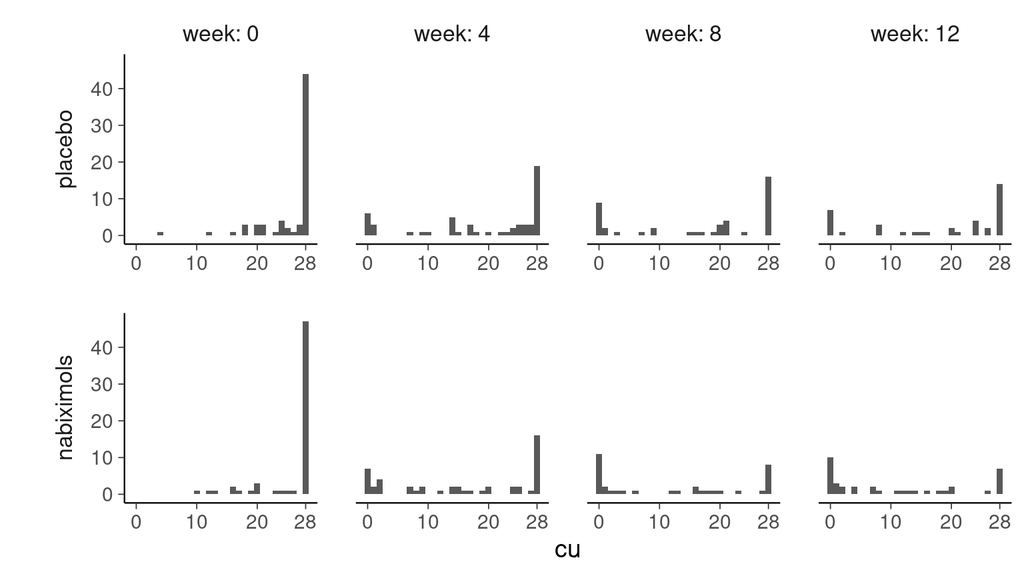

Figure 1

```r
cu_df |>
  ggplot(aes(x = cu)) +
  geom_histogram(breaks = seq(-.5, 28.5, by = 1)) +
  scale_x_continuous(breaks = c(0, 10, 20, 28)) +
  facet_grid(group ~ week, switch = "y", axes = "all_x",
             labeller = labeller(group = label_value, week = label_both)) +
  labs(y = "")
```

# 3 Initial models

Mills provided two `brms` (Bürkner 2017) models with specified priors. The first one is a normal regression model with varying intercept for each participant (`id`).

```r
fit_normal <- brm(formula = cu ~ group*week + (1 | id),
          data = cu_df,
          family = gaussian(),
          prior = c(prior(normal(14, 1.5), class = Intercept),
                    prior(normal(0, 11), class = b),
                    prior(cauchy(1, 2), class = sd)),
          save_pars = save_pars(all = TRUE),
          seed = 1234,
          refresh = 0)
fit_normal <- add_criterion(fit_normal, criterion = "loo", save_psis = TRUE,
                            moment_match = TRUE)
```

The second provided model is a binomial model with the number of trials being $28$ for each outcome (`cu`)

```r
fit_binomial <- brm(formula = cu | trials(set)  ~ group*week + (1 | id),
        data = cu_df,
        binomial(link = logit),
        prior = c(prior(normal(0, 1.5), class = Intercept),
                  prior(normal(0, 1), class = b),
                  prior(cauchy(0, 2), class = sd)),
        save_pars = save_pars(all = TRUE),
        seed = 1234,
        refresh = 0)
fit_binomial <- add_criterion(fit_binomial, criterion = "loo", save_psis = TRUE,
                              moment_match = TRUE)
```

Mills compared the models using PSIS-LOO (Vehtari, Gelman, and Gabry 2017; Vehtari, Gabry, et al. 2024) and asked is this valid:

```r
loo_compare(fit_normal, fit_binomial)
```

```
        model elpd_diff se_diff p_worse diag_diff       diag_elpd
   fit_normal       0.0     0.0      NA
 fit_binomial    -311.8   118.5    1.00           62 k_psis > 0.7
```

# 4 Comparison of discrete and continuous models

At this point I ignore the fact that there many high Pareto-$k$ values indicating unreliable PSIS-LOO estimates (Vehtari, Simpson, et al. 2024), and first discuss comparison of predictive probabilities and predictive probability densities.

I pick the `id=2` and compute the posterior predictive probability of each possible outcome $(0,1,2,\ldots,28)$. At this point we don’t need to consider LOO-CV issues, and can focus on comparison of posterior predictive probabilities. We can use `log_lik()` function to compute the log predictive probabilities. In the following plot the area of each bar is equal to the probability of corresponding count outcome and these probabilities sum to 1. They grey bar illustrates the posterior predictive probability of `cu=12`.

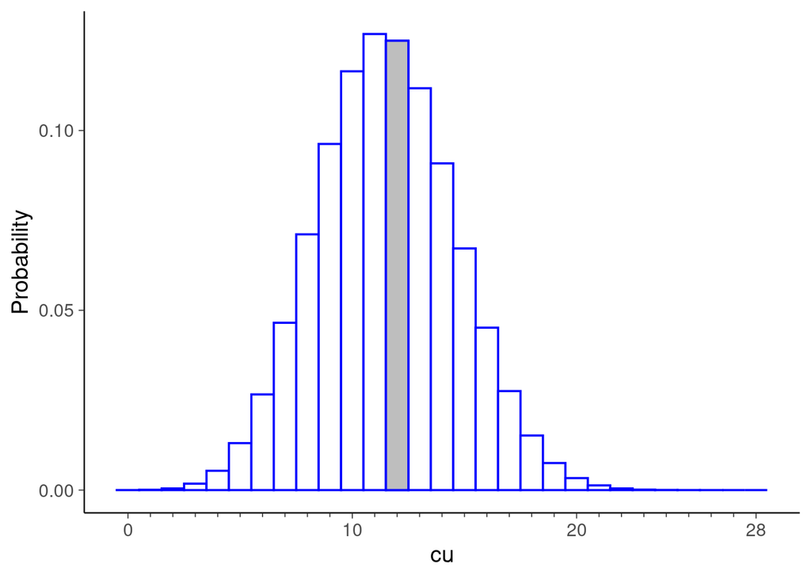

```r
i <- 2
cu_df_predi <- cu_df[i, ] |> select(!cu) |> expand_grid(cu = 0:28)
S <- 4000
p <- exp(colLogSumExps(log_lik(fit_binomial, newdata = cu_df_predi)) - log(S))
predi <- data.frame(cu = 0:28, p = p)
predi |>
  ggplot(aes(x = cu, y = p)) +
  geom_col(width = 1, fill = "white", color = "blue") +
  geom_col(data = predi[cu[i] + 1, ], width = 1, fill = "gray", color = "blue") +
  labs(y = "Probability") +
  scale_x_continuous(breaks = c(0, 10, 20, 28), minor_breaks = 0:28) +
  guides(x = guide_axis(minor.ticks = TRUE))
```

In case of normal model, the observation model is continuous, and we can compute posterior predictive densities. I use `log_lik()` to compute log predictive densities. I compute the predictive density of `cu=12` and predictive density in fine grid for other values (although the observation model is continuous, in practice with computers, we can evaluate the density only in finite number of points). The following plot shows the predictive density and grey line at `cu=12` with end of line corresponding to density at `cu=12`.

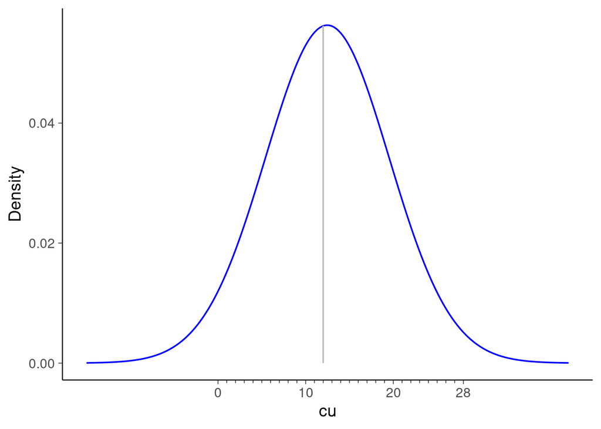

```r
p1 <- exp(colLogSumExps(log_lik(fit_normal, newdata = cu_df[i, ])) - log(S))
cu_pred <- seq(-15, 40, length.out = 400)
cu_df_predi_2 <- cu_df[i, ] |> select(!cu) |> expand_grid(cu = cu_pred)
ll <- log_lik(fit_normal, newdata = cu_df_predi_2)
p <- exp(colLogSumExps(ll) - log(S))
predi <- data.frame(cu = cu_pred, p = p)
pn <- predi |>
  ggplot(aes(x = cu, y = p)) +
  geom_line(color = "blue") +
  annotate(geom = "segment", x = cu_df[i, "cu"], y = 0, xend = cu_df[i, "cu"],
           yend = p1, color = "gray") +
  labs(y = "Density") +
  scale_x_continuous(breaks = c(0, 10, 20, 28), minor_breaks = 0:28) +
  guides(x = guide_axis(minor.ticks = TRUE))
pn
```

We can’t compare probabilities and densities directly, but we can discretize the density to get probabilities. As the outcomes are integers $(0,1,2,\ldots,28)$, we can compute probabilities for intervals $((-0.5, 0.5), (0.5,1.5), (1.5,2.5),\ldots,(27.5,28.5))$. The following plot shows the vertical lines for the edges of these intervals.

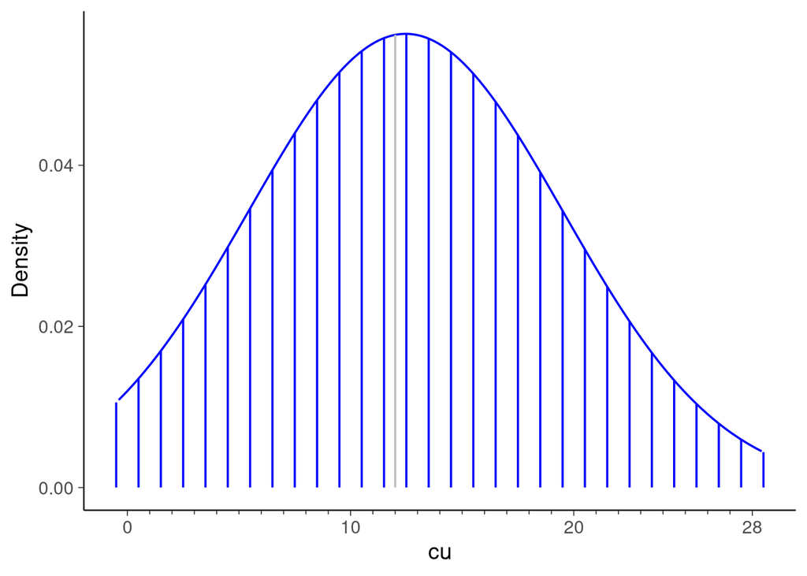

```r
ll2 <- log_lik(fit_normal, newdata = cu_df[i, ] |> select(!cu) |> expand_grid(cu = seq(-0.5, 28.5, by = 1)))
p2 <- exp(colLogSumExps(ll2) - log(S))
pn +
  annotate(geom = "segment", x = seq(-0.5, 28.5, by = 1), y = 0,
           xend = seq(-0.5, 28.5, by = 1), yend = p2, color = "blue") +
  scale_x_continuous(breaks = c(0, 10, 20, 28), minor_breaks = 0:28, lim = c(-0.5, 28.5))
```

We can then integrate the density over the interval. For example, integrate predictive density from $11.5$ to $12.5$ to get a probability that $11.5 < cu < 12.5$ (it doesn’t matter here if the interval ends are open or closed). To simplify the computation, we approximate the density as piecewise constant function shown in the next plot.

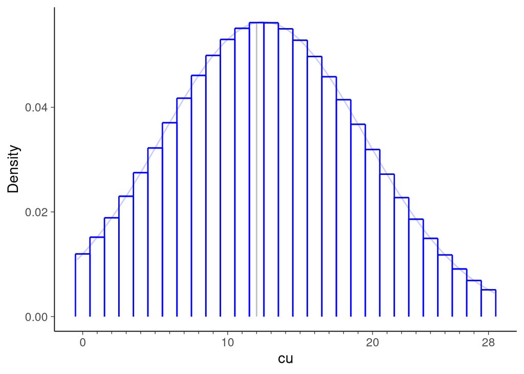

```r
ll3 <- log_lik(fit_normal, newdata = cu_df[i, ] |> select(!cu) |> expand_grid(cu = seq(0, 28, by = 1)))
p3 <- exp(colLogSumExps(ll3) - log(S))
pn <-
  predi |>
  ggplot(aes(x = cu, y = p)) +
  geom_line(color = "blue", alpha = 0.2) +
  annotate(geom = "segment", x = cu_df[i, "cu"], y = 0, xend = cu_df[i, "cu"],
           yend = p1, color = "gray") +
  labs(y = "Density") +
  scale_x_continuous(breaks = c(0, 10, 20, 28), minor_breaks = 0:28, lim = c(-0.5, 28.5)) +
  guides(x = guide_axis(minor.ticks = TRUE))
pn +
  annotate(geom = "segment", x = rep(seq(-0.5, 28.5, by = 1), each = 2)[2:59], y = 0,
           xend = rep(seq(-0.5, 28.5, by = 1), each = 2)[2:59], yend = rep(p3, each = 2), color = "blue") +
  annotate(geom = "segment", x = rep(seq(-0.5, 28.5, by = 1), each = 2)[1:58], y = rep(p3, each = 2),
           xend = rep(seq(-0.5, 28.5, by = 1), each = 2)[3:60], yend = rep(p3, each = 2), color = "blue")
```

Now the probability of each interval is approximated by the height times the width of a bar. The height is the density in the middle of the interval and width of the bar is 1, and thus the probability value is the same as the density value! In this case this is simple as the counts are integers and the distance between counts is 1. The following plot shows the probability of `cu=12`.

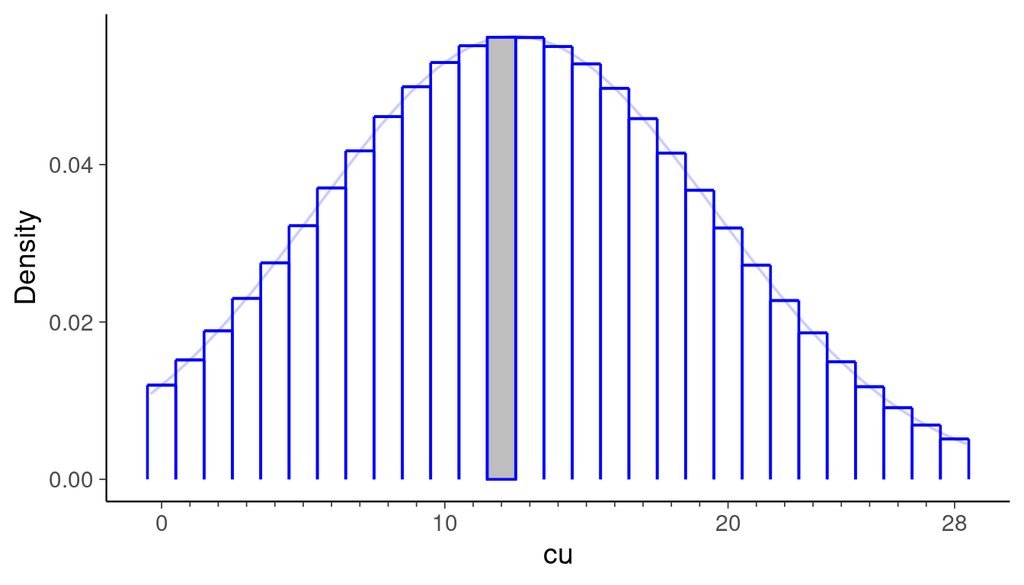

Figure 2

```r
pn +
  annotate(geom = "segment", x = rep(seq(-0.5, 28.5, by = 1), each = 2)[2:59], y = 0,
           xend = rep(seq(-0.5, 28.5, by = 1), each = 2)[2:59], yend = rep(p3, each = 2), color = "blue") +
  annotate(geom = "segment", x = rep(seq(-0.5, 28.5, by = 1), each = 2)[1:58], y = rep(p3, each = 2),
           xend = rep(seq(-0.5, 28.5, by = 1), each = 2)[3:60], yend = rep(p3, each = 2), color = "blue") +
  geom_col(data = data.frame(cu = 12, p = p3[12 + 1]), width = 1, fill = "gray", color = "blue")
```

Thus, in this case, the LOO-ELPD comparison is valid.

The normal model predictions are not constrained between $0$ and $28$ (or $-0.5$ and $28.5$), and thus the probabilities for `cu` $\in (0,1,2,\ldots,28)$ do not necessarily sum to 1.

```r
sum(p3)
```

```
[1] 0.9539372
```

We could switch to truncated normal, but for this data, it would not work well, and as we have better options, I skip illustration of that.

Before continuing with better models, I illustrate the case where the integration interval is not 1, and the comparison would require more work. It is common with continuous targets to normalize the target to have zero mean and unit standard deviation.

```r
cu_scaled_df <- cu_df |>
  mutate(cu_scaled = (cu - mean(cu)) / sd(cu))
```

Fit the normal model with scaled target.

```r
fit_normal_scaled <- brm(formula = cu_scaled ~ group*week + (1 | id),
          data = cu_scaled_df,
          family = gaussian(),
          prior = c(prior(normal(0, 1.5), class = Intercept),
                    prior(normal(0, 11), class = b),
                    prior(cauchy(1, 2), class = sd)),
          save_pars = save_pars(all = TRUE),
          seed = 1234,
          refresh = 0)
fit_normal_scaled <- add_criterion(fit_normal_scaled, criterion = "loo")
```

Now the densities for the scaled target are much higher, and the scaled model seems to be much better.

```r
loo_compare(fit_normal, fit_normal_scaled)
```

```
             model elpd_diff se_diff p_worse diag_diff      diag_elpd
 fit_normal_scaled       0.0     0.0      NA           5 k_psis > 0.7
        fit_normal    -913.2     0.9    1.00
```

However to make a fair comparison, we need to take into account the scaling we used. To get the probabilities for integer counts, the densities need to be multiplied by the discretization binwidth $0.093$. Correspondingly in log scale we add $\log(0.093)$ to each log-density, and the total adjustment is

```r
nrow(cu_df)*log(sd(cu_df$cu))
```

```
[1] 914.2574
```

Adding this to `eldp_loo` of the scaled outcome model, makes the two models to have almost the same `elpd_loo` (the small difference comes from not scaling the priors).

# 5 Model checking

Let’s get back to the first models. The normal model was better than the binomial model in the LOO comparison, but that doesn’t mean it is a good model. Before trying to solve the high Pareto-$k$ issues in LOO computation, we can use posterior predictive checking.

Histograms of posterior predictive replicates show that the binomial model predicts lower probability for both $0$ and $28$ than what is the observed proportion.

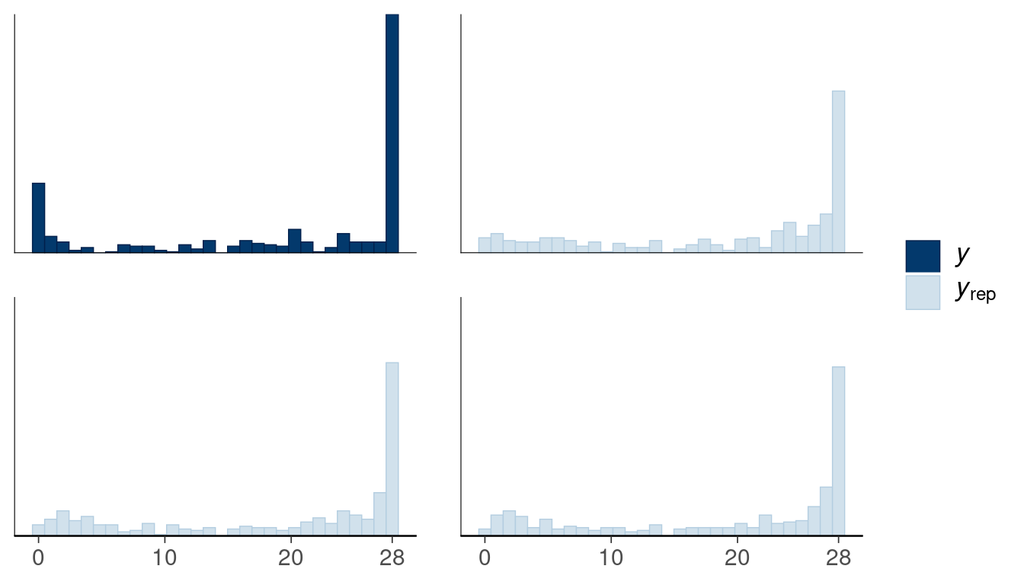

Figure 3

```r
pp_check(fit_binomial, type = "hist", ndraws = 3) +
  scale_x_continuous(breaks = c(0, 10, 20, 28)) +
  theme(axis.line.y = element_blank())
```

We can also look at the marginal distribution of the data and posterior replicates.

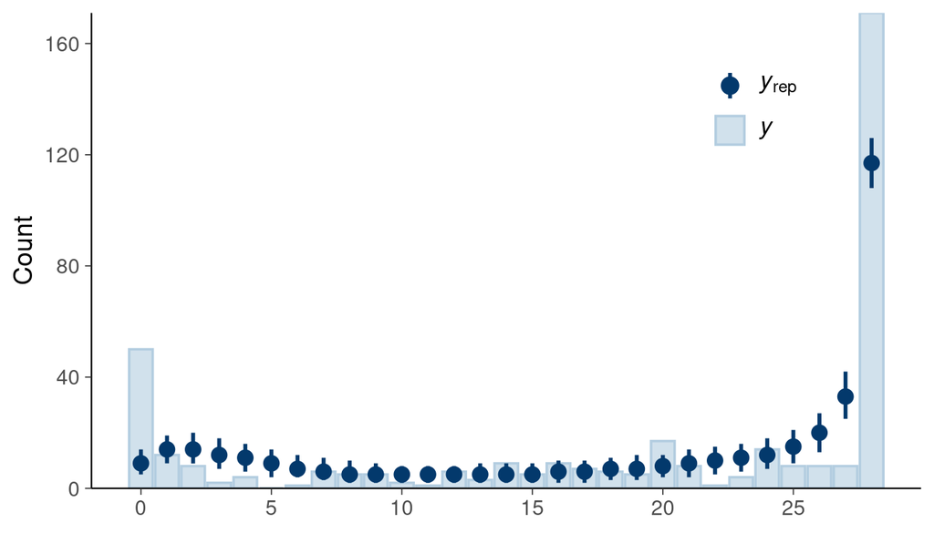

Figure 4

```r
pp_check(fit_binomial, type = "bars", ndraws = 4000) +
  theme(legend.position = "inside",
        legend.position.inside = c(0.8, 0.8))
```

There is a clear mismatch between data and posterior predictive replicates near edges.

This effect can be seen also in LOO-PIT-ECDF calibration check plot (Säilynoja, Bürkner, and Vehtari 2022) which shows that the pointwise predictive distributions are too narrow.

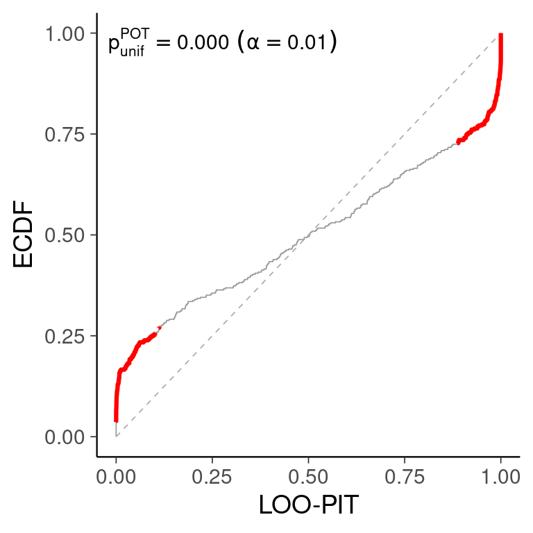

Figure 5

```r
pp_check(fit_binomial, type = "loo_pit_ecdf", method = "correlated")
```

We see that binomial model has too many PIT values near $0$ and $1$, which indicates the posterior predictive intervals are too narrow, and the model is not appropriately handling the overdispersion compared to binomial model, even with included varying intercept term `(1 | id)`.

The normal model posterior predictive replicates look even more different than the observed data, including predicting outcomes less than $0$ and larger than $28$, but the higher probability of $0$ and $28$ makes the difference that the normal model wins in the LOO comparison.

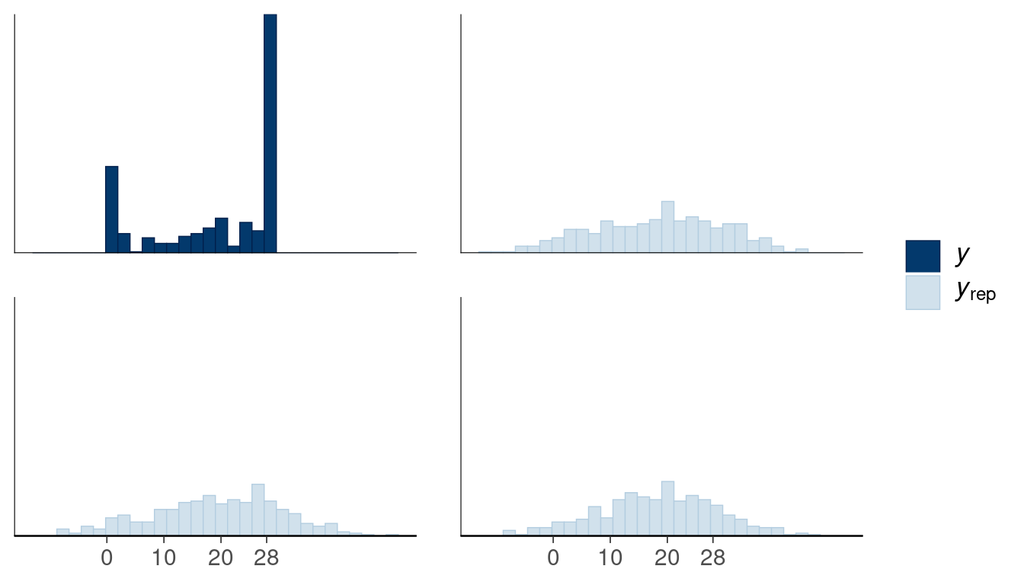

Figure 6

```r
pp_check(fit_normal, type = "hist", ndraws = 3) +
  scale_x_continuous(breaks = c(0, 10, 20, 28)) +
  theme(axis.line.y = element_blank())
```

LOO-PIT-ECDF calibration check plot for normal model does indicate some problem with too few PIT values near 0.5, but surprisingly the miscalibration effects at left and right cancel each other out.

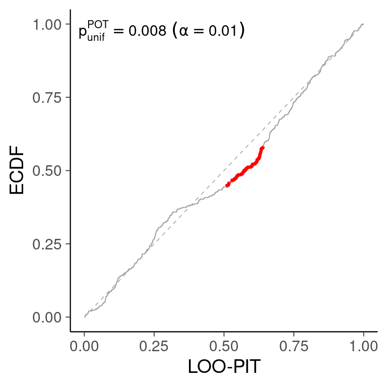

Figure 7

```r
pp_check(fit_normal, type = "loo_pit_ecdf", moment_match = TRUE,
         method = "correlated")
```

We can also examine PIT values computed by comparing all posterior predictive draws with observations marginally, which in this case show the miscalibration very clearly.

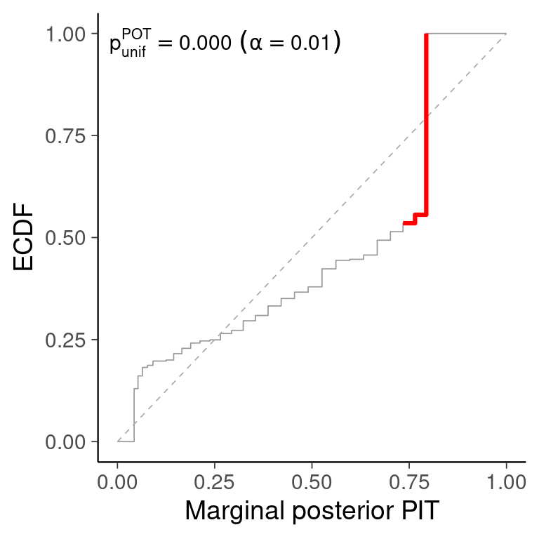

Figure 8

```r
marginal_pit <- function(y, x) {
  pit <- vapply(seq_len(length(y)), function(j) {
    sel_min <- x < y[j]
    if (!any(sel_min)) {
      pit <- 0
    } else {
      pit <- mean(sel_min)
    }
    sel_sup <- x == y[j]
    if (any(sel_sup)) {
      # randomized PIT for discrete y (see, e.g., Czado, C., Gneiting, T.,
      # Held, L.: Predictive model assessment for count data.
      # Biometrics 65(4), 1254–1261 (2009).)
      pit_sup <- pit + mean(sel_sup)
      pit <- runif(1, pit, pit_sup)
    }
  pit
  }, FUN.VALUE = 1.0)
}
ppc_pit_ecdf(pit = marginal_pit(cu_df$cu, posterior_predict(fit_normal)),
             method = "correlated")  +
  labs(x = "Marginal posterior PIT")
```

# 6 Model extension

Binomial model doesn’t have overdispersion term, but the normal model does. How about using beta-binomial model which is an overdispersed version of the binomial model.

```r
fit_betabinomial <- brm(formula = cu | trials(set) ~ group*week + (1 | id),
        data = cu_df,
        beta_binomial(),
        prior = c(prior(normal(0, 1.5), class = Intercept),
                  prior(normal(0, 1), class = b),
                  prior(cauchy(0, 2), class = sd)),
        save_pars = save_pars(all = TRUE),
        seed = 1234,
        refresh = 0)
fit_betabinomial <- add_criterion(fit_betabinomial, criterion = "loo", save_psis = TRUE)
```

```
Warning: Found 13 observations with a pareto_k > 0.7 in model
'fit_betabinomial'. We recommend to set 'moment_match = TRUE' in order to
perform moment matching for problematic observations.
```

```r
loo_compare(fit_normal, fit_binomial, fit_betabinomial)
```

```
Warning: Not all models have the same y variable. ('yhash' attributes do not
match)
```

```
            model elpd_diff se_diff p_worse diag_diff       diag_elpd
 fit_betabinomial       0.0     0.0      NA           13 k_psis > 0.7
       fit_normal    -538.2    33.5    1.00
     fit_binomial    -850.0   111.8    1.00           62 k_psis > 0.7
```

The beta-binomial model beats the normal model big time. The difference is so big that it is unlikely that fixing Pareto-$k$ warnings matter.

# 7 Improved LOO computation

Since in case of high Pareto-$k$ warnings, the estimate is usually optimistic, it is sufficient if we use moment matching (Paananen et al. 2021) for beta-binomial model.

```r
fit_betabinomial <- add_criterion(fit_betabinomial, criterion = "loo",
                                  save_psis = TRUE,
                                  moment_match = TRUE,
                                  overwrite = TRUE)
```

Moment matching gets all Pareto-$k$ values below the diagnostic threshold. There is negligible change in the comparison results.

```r
loo_compare(fit_normal, fit_binomial, fit_betabinomial)
```

```
Warning: Not all models have the same y variable. ('yhash' attributes do not
match)
```

```
            model elpd_diff se_diff p_worse diag_diff       diag_elpd
 fit_betabinomial       0.0     0.0      NA
       fit_normal    -538.9    33.5    1.00
     fit_binomial    -850.7   111.8    1.00           62 k_psis > 0.7
```

Truncated normal might get closer to beta-binomial than normal, but as I said it had difficulties here, and since beta-binomial is proper discrete observation model, I continue with that.

# 8 Model checking

The posterior predictive replicates from beta-binomial look very much like the original data.

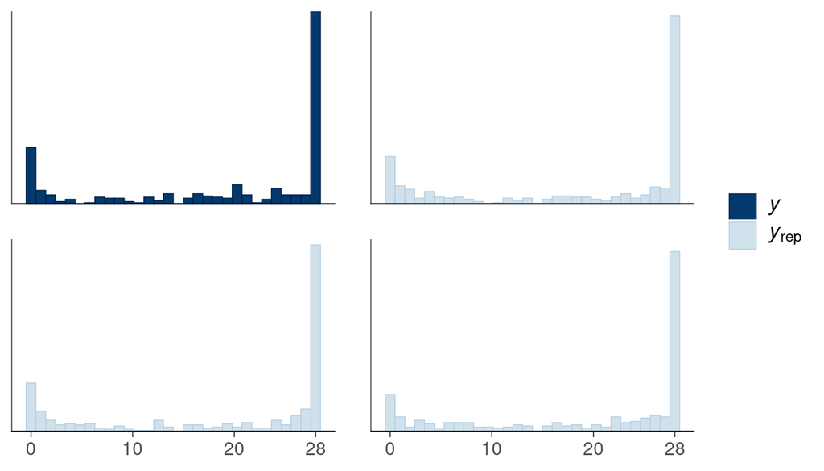

Figure 9

```r
pp_check(fit_betabinomial, type = "hist", ndraws = 3) +
  scale_x_continuous(breaks = c(0, 10, 20, 28)) +
  theme(axis.line.y = element_blank())
```

We can also look at the marginal distribution of the data and posterior replicates.

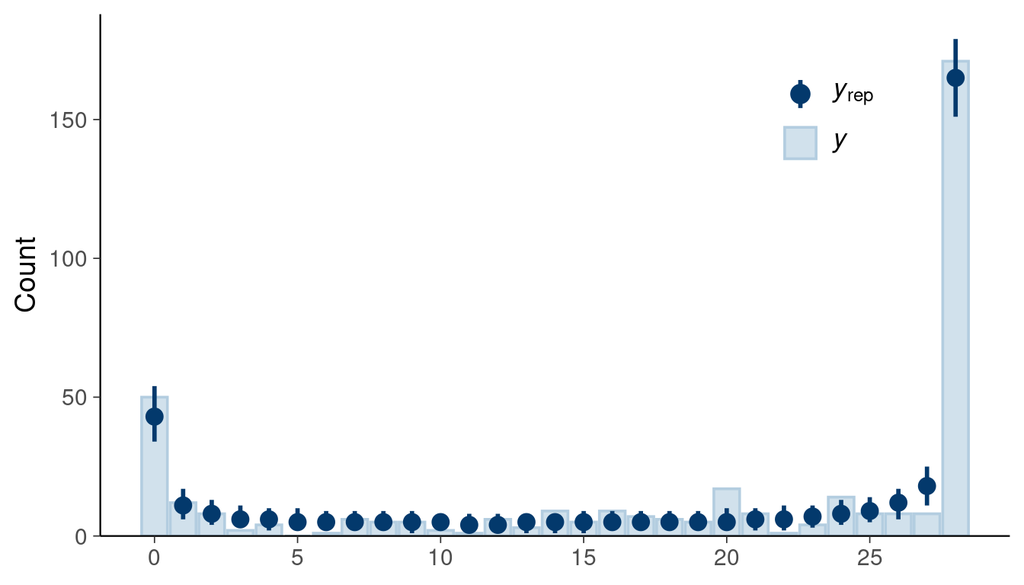

Figure 10

```r
pp_check(fit_betabinomial, type = "bars", ndraws = 4000) +
  theme(legend.position = "inside",
        legend.position.inside = c(0.8, 0.8))
```

This plot looks much better than with binomial model, although data seem to have more variation.

LOO-PIT-ECDF calibration looks very nice and also better than for the normal model.

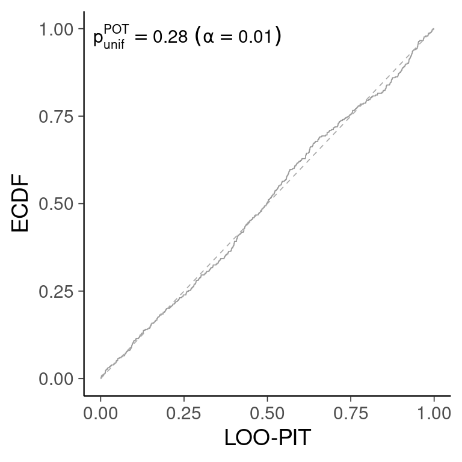

Figure 11

```r
pp_check(fit_betabinomial, type = "loo_pit_ecdf", moment_match = TRUE,
         method = "correlated")
```

The hierarchical beta-binomial model can also be used to illustrate the importance for using crossvalidation for computing PIT values. If we use the same observations to fit the model and check the model, the double use of the data leads to too many PIT values near 0.5 which shows an S-shape in the PIT-ECDF plot.

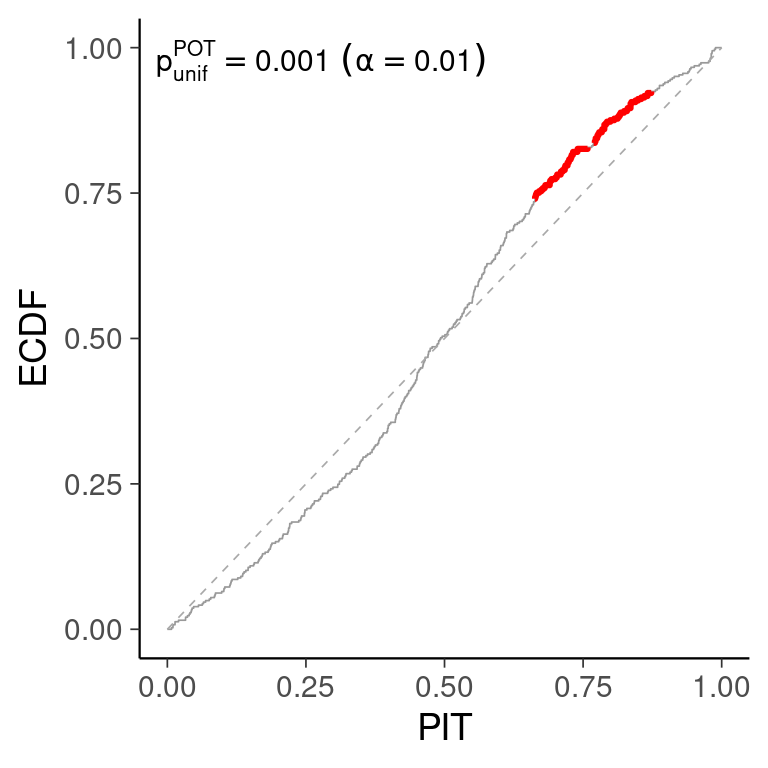

Figure 12

```r
pp_check(fit_betabinomial, type = "pit_ecdf", method = "correlated")
```

The data included many counts of $0$ and $28$, and we can further check whether we might need to include zero-inflation or $28$-inflation model component. As illustrated in [Roaches case study](https://users.aalto.fi/~ave/modelselection/roaches.html) PIT’s may sometimes be weak to detect zero-inflation, but reliability diagram (Dimitriadis, Gneiting, and Jordan 2021) can focus there in more detail.

Calibration check with reliability diagram for $0$ vs others

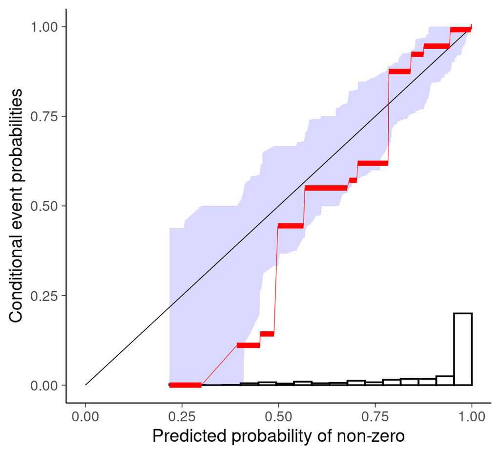

Figure 13

```r
th <- 0
rd <- reliabilitydiag(
  EMOS = pmin(E_loo(0 + (posterior_predict(fit_betabinomial) > th),
                    loo(fit_betabinomial)$psis_object)$value, 1),
  y = as.numeric(cu_df$cu > th)
)
autoplot(rd) +
  labs(x = "Predicted probability of non-zero",
       y = "Conditional event probabilities") +
  bayesplot::theme_default(base_family = "sans", base_size = 14)
```

Calibration check with reliability diagram for $28$ vs others

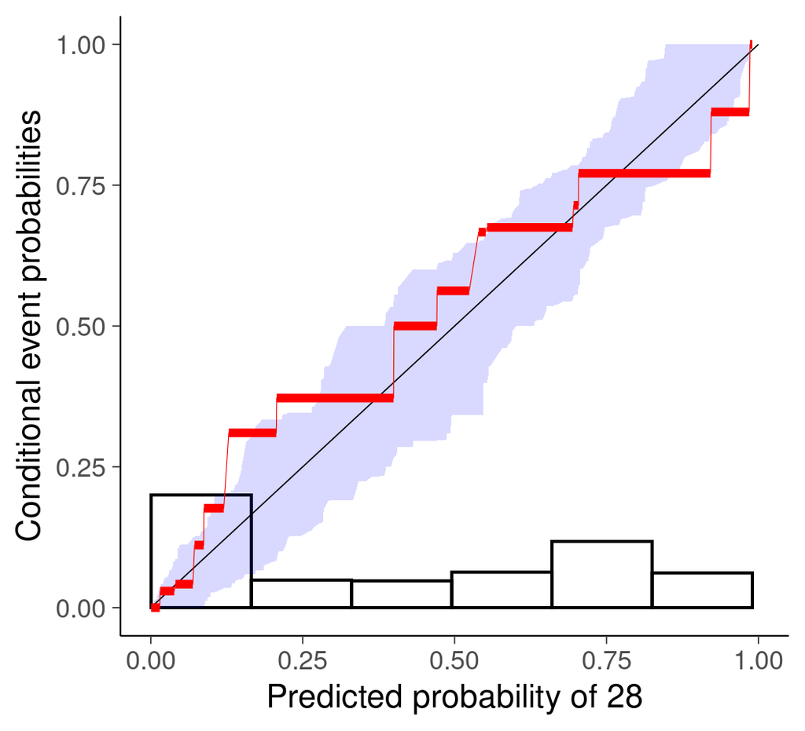

Figure 14

```r
th <- 27
rd <- reliabilitydiag(
  EMOS = pmin(E_loo(0 + (posterior_predict(fit_betabinomial) > th),
                    loo(fit_betabinomial)$psis_object)$value, 1),
  y = as.numeric(cu_df$cu > th)
)
autoplot(rd) +
  labs(x = "Predicted probability of 28",
       y = "Conditional event probabilities") +
  bayesplot::theme_default(base_family = "sans", base_size = 16)
```

Although the red line did not completely stay within blue envelope, these look good.

# 9 Prior sensitivity analysis

The priors provided by Mills seems a bit narrow, so I do prior-likelihood sensitivity analysis using powerscaling approach (Kallioinen et al. 2023).

```r
powerscale_sensitivity(fit_betabinomial,
                       variable = variables(as_draws(fit_betabinomial))[1:11]) |>
  tt() |>
  format_tt(num_fmt = "decimal")
```

| variable | prior | likelihood | diagnosis |
| --- | --- | --- | --- |
| b_Intercept | 0.15 | 0.54 | potential prior-likelihood conflict |
| b_groupnabiximols | 0.09 | 0.09 | potential prior-likelihood conflict |
| b_week4 | 0.15 | 0.35 | potential prior-likelihood conflict |
| b_week8 | 0.18 | 0.41 | potential prior-likelihood conflict |
| b_week12 | 0.15 | 0.42 | potential prior-likelihood conflict |
| b_groupnabiximols:week4 | 0.11 | 0.2 | potential prior-likelihood conflict |
| b_groupnabiximols:week8 | 0.09 | 0.1 | potential prior-likelihood conflict |
| b_groupnabiximols:week12 | 0.12 | 0.23 | potential prior-likelihood conflict |
| sd_id__Intercept | 0.11 | 0.62 | potential prior-likelihood conflict |
| phi | 0.19 | 0.96 | potential prior-likelihood conflict |
| Intercept | 0.1 | 0.44 | potential prior-likelihood conflict |

There are prior-data conflicts for all global parameters. It is possible that the priors had been chosen based on substantial prior information and then the posterior should be influenced by the prior, too, and the conflict is not necessarily a problem.

# 10 Alternative priors

However, I decided to try slightly wider priors, especially as the data seem to be quite informative

```r
fit_betabinomial2 <- brm(formula = cu | trials(set) ~ group*week + (1 | id),
        data = cu_df,
        beta_binomial(),
        prior = c(prior(normal(0, 3), class = Intercept),
                  prior(normal(0, 3), class = b),
                  prior(normal(0, 3), class = sd)),
        save_pars = save_pars(all = TRUE),
        seed = 1234,
        refresh = 0)
```

```r
powerscale_sensitivity(fit_betabinomial2,
                       variable = variables(as_draws(fit_betabinomial2))[1:11]) |>
  tt() |>
  format_tt(num_fmt = "decimal")
```

| variable | prior | likelihood | diagnosis |
| --- | --- | --- | --- |
| b_Intercept | 0.03 | 0.41 | - |
| b_groupnabiximols | 0.02 | 0.03 | - |
| b_week4 | 0.03 | 0.29 | - |
| b_week8 | 0.03 | 0.36 | - |
| b_week12 | 0.03 | 0.3 | - |
| b_groupnabiximols:week4 | 0.02 | 0.14 | - |
| b_groupnabiximols:week8 | 0.02 | 0.1 | - |
| b_groupnabiximols:week12 | 0.02 | 0.17 | - |
| sd_id__Intercept | 0.03 | 0.54 | - |
| phi | 0.05 | 0.81 | potential prior-likelihood conflict |
| Intercept | 0.03 | 0.44 | - |

We can also do LOO comparison, which indicates that the wider priors provide a tiny bit better predictive performance.

```r
fit_betabinomial2 <- add_criterion(fit_betabinomial2, criterion = "loo",
                                   save_psis = TRUE, moment_match = TRUE,
                                   overwrite = TRUE)
```

```r
loo_compare(fit_betabinomial, fit_betabinomial2)
```

```
             model elpd_diff se_diff p_worse       diag_diff diag_elpd
 fit_betabinomial2       0.0     0.0      NA
  fit_betabinomial      -1.2     2.6    0.68 |elpd_diff| < 4
```

# 11 Model refinement

All the above models included the baseline `week=0` in the interaction term with `group`, which does not make sense as the group should not affect the baseline. I modify the data and models by moving the baseline `week=0` `cu`s to be pre-treatment covariate.

```r
cu_df_b <- cu_df |> dplyr::filter(week != 0) |>
  mutate(week = droplevels(week))
cu_df_b <- left_join(cu_df_b,
                     cu_df |> dplyr::filter(week == 0) |> select(id, cu),
                     by = "id",
                     suffix = c("", "_baseline"))
fit_betabinomial2b <- brm(formula = cu | trials(set) ~ group*week + cu_baseline + (1 | id),
        data = cu_df_b,
        beta_binomial(),
        prior = c(prior(normal(0, 3), class = Intercept),
                  prior(normal(0, 3), class = b)),
        save_pars = save_pars(all = TRUE),
        seed = 1234,
        refresh = 0)
fit_betabinomial2b <- add_criterion(fit_betabinomial2b, criterion = "loo",
                                    save_psis = TRUE, moment_match = TRUE)
```

To compare the new model against the previous ones, we exclude the pointwise elpds for week 0.

```r
loo2 <- loo(fit_betabinomial2)
loo2$pointwise <- loo2$pointwise[cu_df$week != "0", ]
loo_compare(loo2, loo(fit_betabinomial2b))
```

```
Warning: Not all models have the same y variable. ('yhash' attributes do not
match)
```

```
              model elpd_diff se_diff p_worse diag_diff      diag_elpd
 fit_betabinomial2b       0.0     0.0      NA           3 k_psis > 0.7
  fit_betabinomial2     -35.5     9.7    1.00
```

The quick fix to exclude week 0, does not change the `yhash` and we get a warning which we can ignore. The new model is clearly better than the previous best model.

By comparing `phi` parameter posteriors, we see that the overdispersion of the beta-binomial in the new model is smaller (smaller `phi` means bigger overdispersion).

```r
as_draws_df(fit_betabinomial2) |>
  subset_draws(variable = "phi") |>
  summarise_draws() |>
  tt()
```

| variable | mean | median | sd | mad | q5 | q95 | rhat | ess_bulk | ess_tail |
| --- | --- | --- | --- | --- | --- | --- | --- | --- | --- |
| phi | 1.7 | 1.7 | 0.25 | 0.25 | 1.3 | 2.2 | 1 | 2000 | 2623 |

```r
as_draws_df(fit_betabinomial2b) |>
  subset_draws(variable = "phi") |>
  summarise_draws() |>
  tt()
```

| variable | mean | median | sd | mad | q5 | q95 | rhat | ess_bulk | ess_tail |
| --- | --- | --- | --- | --- | --- | --- | --- | --- | --- |
| phi | 3.8 | 3.7 | 0.72 | 0.71 | 2.7 | 5.1 | 1 | 1592 | 2179 |

# 12 Model checking

The marginal distribution of the posterior replicates matches the data better than earlier models.

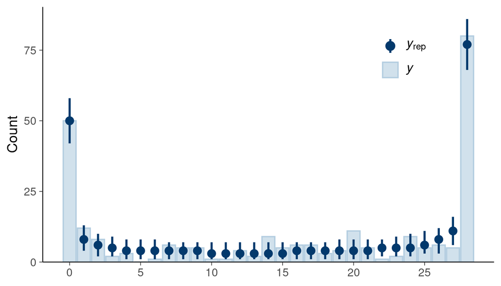

Figure 15

```r
pp_check(fit_betabinomial2b, type = "bars", ndraws = 4000) +
  theme(legend.position = "inside",
        legend.position.inside = c(0.8, 0.8))
```

LOO-PIT-ECDF plot looks good:

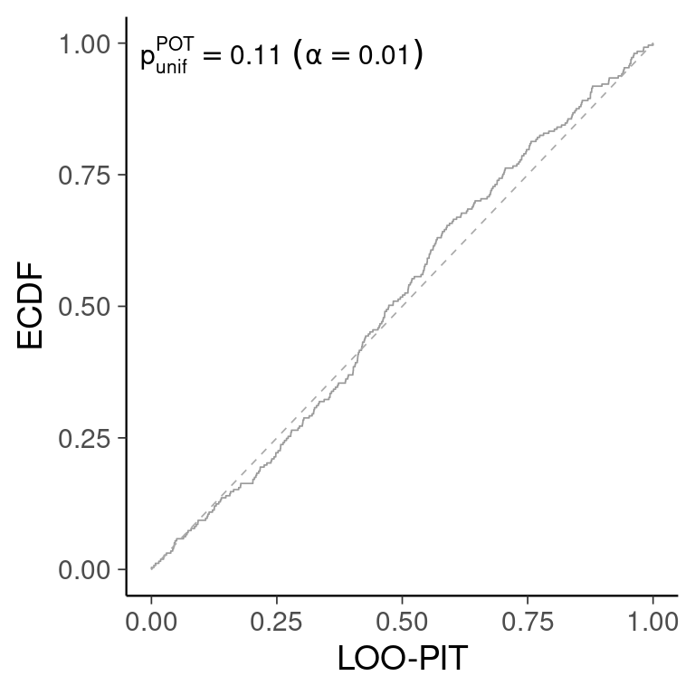

Figure 16

```r
pp_check(fit_betabinomial2b, type = "loo_pit_ecdf", moment_match = TRUE,
         method = "correlated")
```

Calibration check with reliability diagrams for $0$ vs others and $28$ vs others look better than for the previous model.

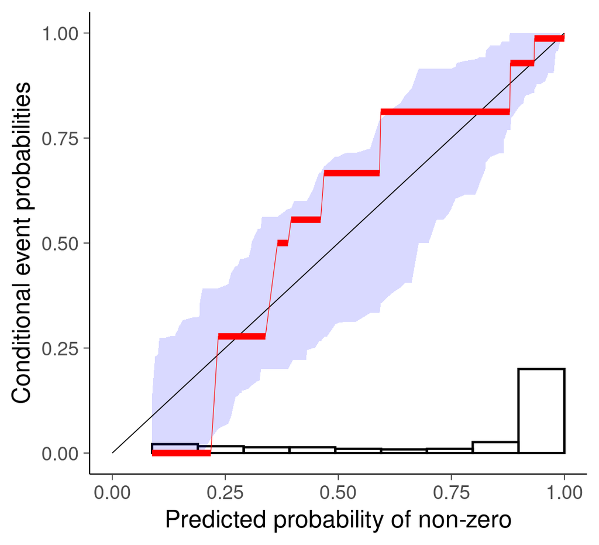

Figure 17

```r
th <- 0
rd <- reliabilitydiag(
  EMOS = pmin(E_loo(0 + (posterior_predict(fit_betabinomial2b) > th),
                    loo(fit_betabinomial2b)$psis_object)$value, 1),
  y = as.numeric(cu_df_b$cu > th)
)
autoplot(rd) +
  labs(x = "Predicted probability of non-zero",
       y = "Conditional event probabilities") +
  bayesplot::theme_default(base_family = "sans", base_size = 16)
```

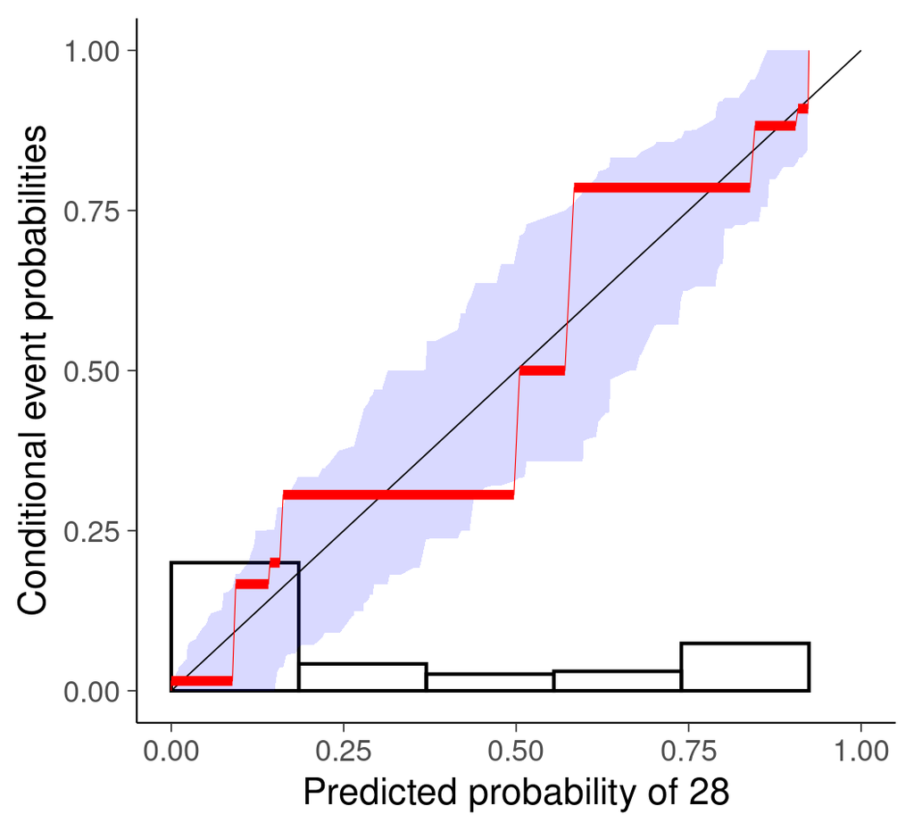

Figure 18

```r
th <- 27
rd <- reliabilitydiag(
  EMOS = pmin(E_loo(0 + (posterior_predict(fit_betabinomial2b) > th),
                    loo(fit_betabinomial2b)$psis_object)$value, 1),
  y = as.numeric(cu_df_b$cu > th)
)
autoplot(rd) +
  labs(x = "Predicted probability of 28",
       y = "Conditional event probabilities") +
  bayesplot::theme_default(base_family = "sans", base_size = 16)
```

# 13 Treatment effect

As the treatment is included in interaction term, looking at the univariate posterior marginal is not sufficient for checking whether the treatment helps.

We can examine the effect of the treatment by looking at the posterior predictive distribution and the expectation of the posterior predictive distribution for a new person (new `id`). For each person we can compare the prediction to the counterfactual case, that is, what if that person would have been in the other treatment group. We can compare the difference from being in the placebo to being in the Nabiximols group.

We use `tidybayes` (Kay 2023) and `ggdist` (Kay 2024) to generate and plot predictions.

We start by examining the posterior predictive distribution. We predict `cu` for a new `id=129` given `cu_baseline=28` (median value). The distribution is wide as it included the aleatoric uncertainty from the unknown `id` specific intercept and beta-binomial distribution.

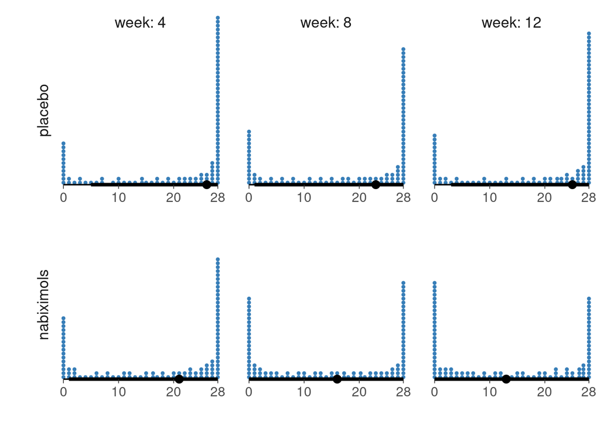

Figure 19

```r
cu_df_b |>
  data_grid(group, week, cu_baseline = 28, id = 129, set = 28) |>
  add_predicted_draws(fit_betabinomial2b, allow_new_levels = TRUE) |>
  ggplot(aes(x = .prediction)) +
  facet_grid(group ~ week, switch = "y", axes = "all_x",
             labeller = labeller(group = label_value, week = label_both)) +
  stat_dotsinterval(quantiles = 100, fill = set1[2], slab_color = set1[2],
                    binwidth = 2/3, overflow = "keep") +
  coord_cartesian(expand = FALSE, clip = "off") +
  theme(strip.background = element_blank(), strip.placement = "outside") +
  labs(x = "", y = "") +
  scale_x_continuous(breaks = c(0, 10, 20, 28), lim = c(-0.5, 28.5)) +
  theme(axis.line.y = element_blank(),
        axis.text.y = element_blank(),
        axis.ticks.y = element_blank(),
        axis.line.x = element_blank())
```

The difference between groups is the biggest in week 12. The next plot shows the comparison of predicted `cu` between the groups in different weeks.

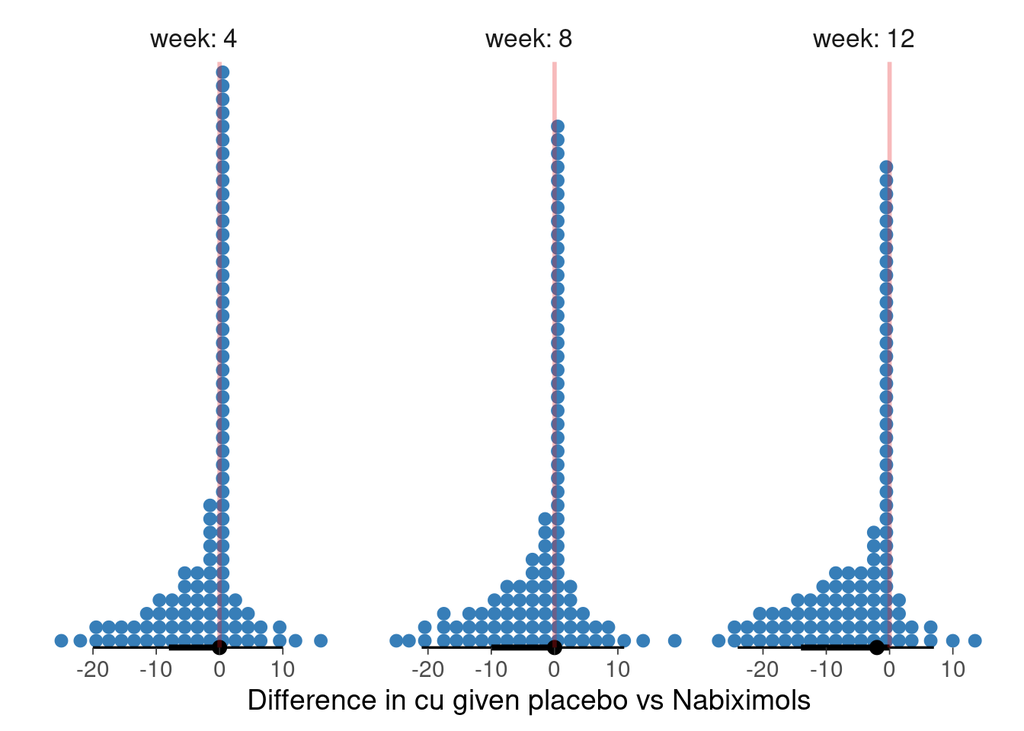

Figure 20

```r
cu_df_b |>
  data_grid(group, week, cu_baseline = 28, id = 129, set = 28) |>
  add_predicted_draws(fit_betabinomial2b, allow_new_levels = TRUE) |>
  compare_levels(.prediction, by = group) |>
  ggplot(aes(x = .prediction)) +
  facet_grid(. ~ week, switch = "y", axes = "all_x",
             labeller = labeller(group = label_value, week = label_both)) +
  stat_dotsinterval(quantiles = 100, fill = set1[2], slab_color = set1[2],
                    binwidth = 2, overflow = "keep") +
  coord_cartesian(expand = FALSE, clip = "off") +
  theme(strip.background = element_blank(), strip.placement = "outside") +
  labs(x = "Difference in cu given placebo vs Nabiximols", y = "") +
  geom_vline(xintercept = 0, color = set1[1], linewidth = 1, alpha = 0.3) +
  theme(axis.line.y = element_blank(),
        axis.text.y = element_blank(),
        axis.ticks.y = element_blank(),
        axis.line.x = element_blank())
```

For comparison I plot 1) the ggplot2 default KDE with stat_density, 2) ggdist KDE with stat_slabinterval, and 3) ggplot default histogram with stat_histogram for the week 12 difference. The ggplot2 KDE oversmooths a lot, the ggdist KDE and ggplot2 histogram smooth less, but it is not as easy to estimate the tail probabilities as with dots plot.

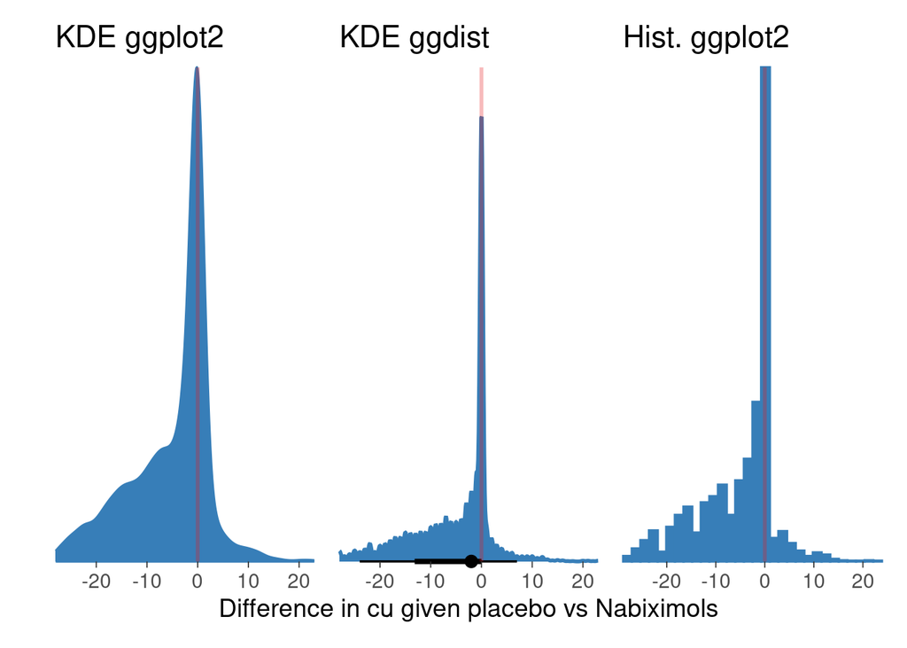

Figure 21

```r
pp <- cu_df_b |>
  data_grid(group, week = 12, cu_baseline = 28, id = 129, set = 28) |>
  add_predicted_draws(fit_betabinomial2b, allow_new_levels = TRUE) |>
  compare_levels(.prediction, by = group) |>
  ggplot(aes(x = .prediction)) +
  coord_cartesian(expand = FALSE, clip = "off") +
  theme(strip.background = element_blank(), strip.placement = "outside") +
  labs(x = "Difference in cu given placebo vs Nabiximols", y = "") +
 theme(axis.line.y = element_blank(),
        axis.text.y = element_blank(),
        axis.ticks.y = element_blank(),
        axis.line.x = element_blank())
(pp + stat_density(fill = set1[2], color = set1[2]) + labs(title = "KDE ggplot2") +
  geom_vline(xintercept = 0, color = set1[1], linewidth = 1, alpha = 0.3)) +
(pp + stat_slabinterval(fill = set1[2], slab_color = set1[2]) + labs(title = "KDE ggdist") +
  geom_vline(xintercept = 0, color = set1[1], linewidth = 1, alpha = 0.3)) +
(pp + geom_histogram(fill = set1[2], color = set1[2]) + labs(title = "Hist. ggplot2") +
   geom_vline(xintercept = 0, color = set1[1], linewidth = 1, alpha = 0.3)) +
  plot_layout(axes = "collect")
```

To get more accuracy we can remove the aleatoric uncertainty and focus on expected effect. The following plots shows the expectation of the posterior predictive distribution for `cu` for a new `id=129` given `cu_baseline=28` (expectation as in average over many new individuals). The distribution is much narrower as it includes only the epistemic uncertainty, but not the aleatoric uncertainty (using `re_formula=NA` excludes the uncertainty in the unknown `id` specific intercept and using `_epred` gives just the expectation excluding the uncertainty in beta-binomial distribution).

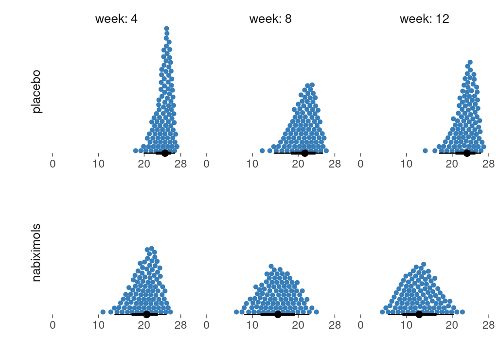

Figure 22

```r
cu_df_b |>
  data_grid(group, week, cu_baseline = 28, id = 129, set = 28) |>
  add_epred_draws(fit_betabinomial2b, re_formula = NA, allow_new_levels = TRUE) |>
  ggplot(aes(x = .epred)) +
  facet_grid(group ~ week, switch = "y", axes = "all_x",
             labeller = labeller(group = label_value, week = label_both)) +
  stat_dotsinterval(quantiles = 100, fill = set1[2], slab_color = set1[2],
                    layout = "swarm", binwidth = 1, overflow = "keep") +
  coord_cartesian(expand = FALSE, clip = "off") +
  theme(strip.background = element_blank(), strip.placement = "outside") +
  labs(x = "", y = "") +
  scale_x_continuous(breaks = c(0, 10, 20, 28), lim = c(-0.5, 28.5)) +
  ylim(c(0, 1)) +
  theme(axis.line.y = element_blank(),
        axis.text.y = element_blank(),
        axis.ticks.y = element_blank(),
        axis.line.x = element_blank())
```

The next plot shows the comparison of expected `cu` between the groups in different weeks.

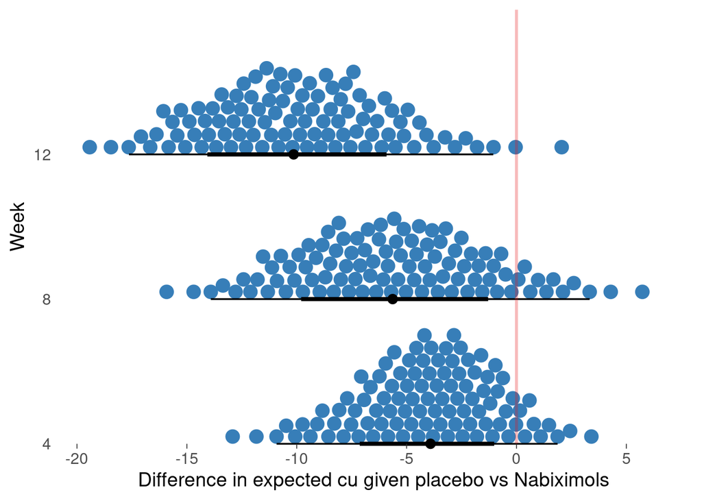

Figure 23

```r
cu_df_b |>
  data_grid(group, week, cu_baseline = 28, id = 129, set = 28) |>
  add_epred_draws(fit_betabinomial2b, re_formula = NA, allow_new_levels = TRUE) |>
  compare_levels(.epred, by = group) |>
  ggplot(aes(x = .epred, y = week)) +
  stat_dotsinterval(quantiles = 100, fill = set1[2], slab_color = set1[2], layout = "swarm") +
  coord_cartesian(expand = FALSE, clip = "off") +
  scale_x_continuous(breaks = seq(-20, 5, by = 5), lim = c(-21, 8)) +
  theme(strip.background = element_blank(), strip.placement = "outside") +
  labs(x = "Difference in expected cu given placebo vs Nabiximols", y = "Week") +
  geom_vline(xintercept = 0, color = set1[1], linewidth = 1, alpha = 0.3) +
  theme(axis.line.y = element_blank(),
        axis.ticks.y = element_blank(),
        axis.line.x = element_blank())
```

For new individuals the posterior predictive distribution indicates 99% possibility of smaller expected `cu` with Nabiximols than with placebo.

```r
cu_df_b |>
  data_grid(group, week = 12, cu_baseline = 28, id = 129, set = 28) |>
  add_epred_draws(fit_betabinomial2b, re_formula = NA, allow_new_levels = TRUE) |>
  compare_levels(.epred, by = group) |>
  mutate(p = as.numeric(.epred < 0)) |>
  pull("p") |>
  mean()
```

```
[1] 0.98525
```

# 14 Prior and likelihood sensitivity of treatment effect posteriors

Examining the prior and likelihood sensitivity of parameter posteriors is quick and easy, but eventually we want to examine prior and likelihood sensitivity of our main quantity of interest, which in this case is the treatment effect in different weeks. Making this analysis requires a bit more code as we need to compute the treatment effect posteriors and combine that information with log prior density and log likelihood for the corresponding posterior draws.

Prior-likelihood sensitivity analysis using powerscaling approach for the treatment effect posteriors at weeks 4, 8, and 12

```r
trt_effect_draws <- cu_df_b |>
  data_grid(group, week, cu_baseline = 28, id = 129, set = 28) |>
  add_epred_draws(fit_betabinomial2b, re_formula = NA, allow_new_levels = TRUE) |>
  compare_levels(.epred, by = group) |>
  ungroup() |>
  pivot_wider(names_from = c(group,week), values_from = .epred, names_sep = " week ") |>
  select(!c(.chain,.iteration)) |>
  left_join(as_draws_df(log_lik_draws(fit_betabinomial2b)), by = ".draw") |>
  left_join(as_draws_df(log_prior_draws(fit_betabinomial2b)), by = ".draw") |>
  as_draws_df() |>
  rename_variables(`nabiximols - placebo week  4`=`nabiximols - placebo week 4`,
                   `nabiximols - placebo week  8`=`nabiximols - placebo week 8`,) |>
  subset_draws(variable = c("nabiximols - placebo week  4",
                            "nabiximols - placebo week  8",
                            "nabiximols - placebo week 12",
                            "log_lik",
                            "lprior"))
```

```
Sensitivity based on cjs_dist
Prior selection: all priors
Likelihood selection: all data

                     variable prior likelihood diagnosis
 nabiximols - placebo week  4 0.015      0.049         -
 nabiximols - placebo week  8 0.010      0.048         -
 nabiximols - placebo week 12 0.014      0.065         -
```

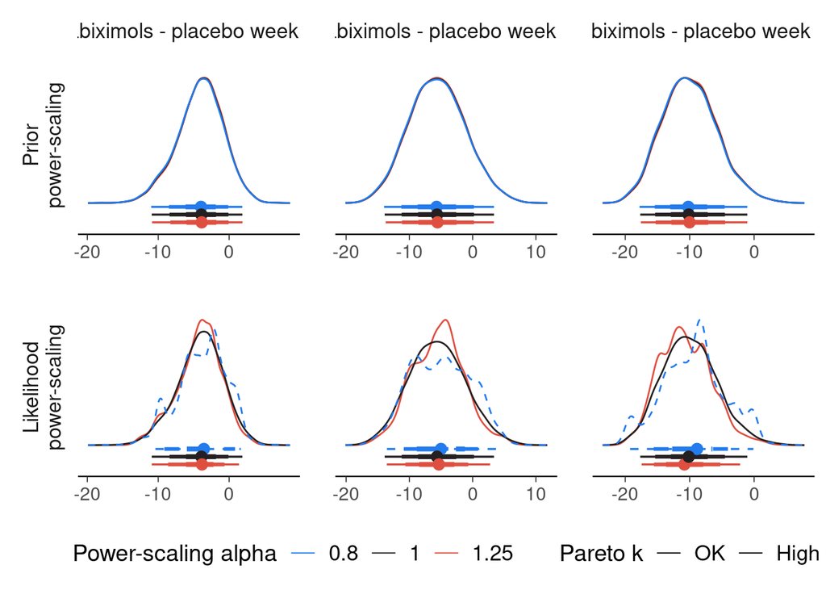

Figure 24

```r
trt_effect_draws |> powerscale_plot_dens(help_text = FALSE)

trt_effect_draws |> powerscale_sensitivity()
```

The treatment effect posteriors are not sensitive to prior and are informed by the likelihood.

# 15 Sensitivity to model choice

Finally we check how much there is difference in the conclusions, if we had used the continuous normal model. We include also models that are closer to the model reported by Lintzeris et al. (2019), which used sum of days of cannabis use across the 12-week trial (the follow-up paper by Lintzeris et al. (2020) considered several 4 week intervals). We build normal and beta-binomial models which match the model in the paper, expect that we don’t include site factor as this was not available for us.

```r
fit_normal2b <- brm(formula = cu ~ group*week + cu_baseline + (1 | id),
        data = cu_df_b,
        gaussian(),
        prior = c(prior(normal(0, 3), class = Intercept),
                  prior(normal(0, 3), class = b)),
        save_pars = save_pars(all = TRUE),
        seed = 1234,
        refresh = 0)
fit_normal2b <- add_criterion(fit_normal2b, criterion = "loo",
                                    save_psis = TRUE, moment_match = TRUE)
```

LOO-PIT-ECDF shows miscalibration

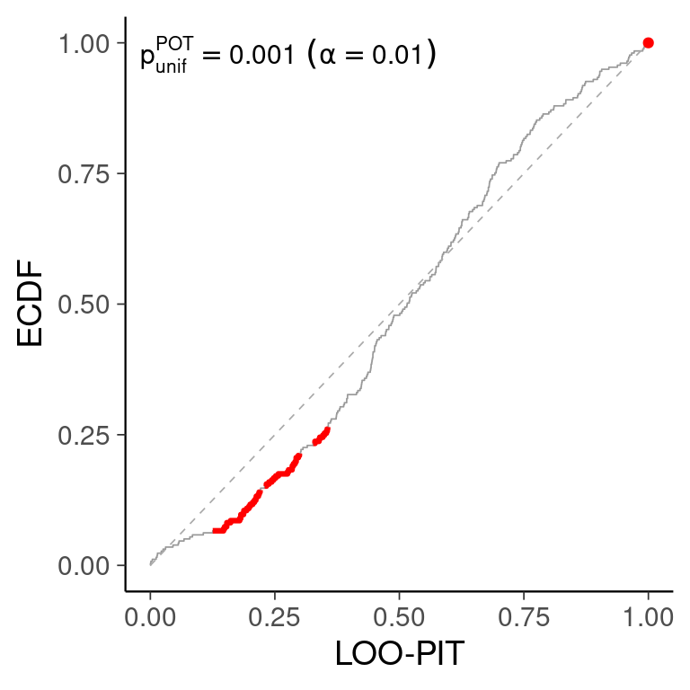

Figure 25

```r
pp_check(fit_normal2b, type = "loo_pit_ecdf", moment_match = TRUE,
         method = "correlated")
```

Marginal PIT-ECDF shows clear miscalibration

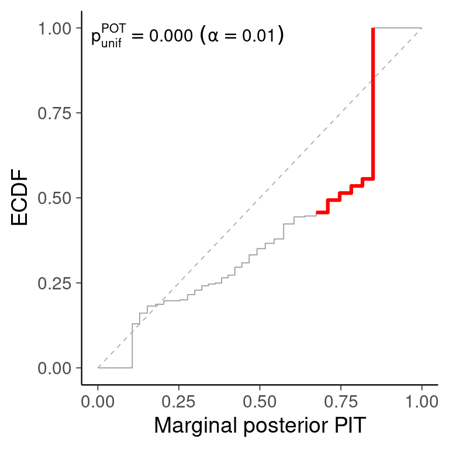

Figure 26

```r
ppc_pit_ecdf(pit = marginal_pit(cu_df$cu, posterior_predict(fit_normal2b)),
             method = "correlated") +
  labs(x = "Marginal posterior PIT")
```

The beta-binomial model beats the normal model big time.

```r
loo_compare(fit_normal2b, fit_betabinomial2b)
```

```
              model elpd_diff se_diff p_worse diag_diff      diag_elpd
 fit_betabinomial2b       0.0     0.0      NA           3 k_psis > 0.7
       fit_normal2b    -268.3    23.2    1.00           5 k_psis > 0.7
```

Next we build models predicting total cu for all weeks (except 0), by dropping week covariate.

```r
cu_df_c <- cu_df_b |>
  group_by(id, group, cu_baseline) |>
  summarise(cu_total = sum(cu), set_total = sum(set)) |>
  as.data.frame()
fit_normal2c <- brm(formula = cu_total ~ group + cu_baseline,
        data = cu_df_c,
        family = gaussian(),
        prior = c(prior(normal(0, 3), class = Intercept),
                  prior(normal(0, 3), class = b)),
        save_pars = save_pars(all = TRUE),
        seed = 1234,
        refresh = 0)
fit_normal2c <- add_criterion(fit_normal2c, criterion = "loo",
                              save_psis = TRUE, moment_match = TRUE)
```

```r
fit_betabinomial2c <- brm(formula = cu_total | trials(set_total) ~ group + cu_baseline,
        data = cu_df_c,
        beta_binomial(),
        prior = c(prior(normal(0, 3), class = Intercept),
                  prior(normal(0, 3), class = b)),
        save_pars = save_pars(all = TRUE),
        seed = 1234,
        refresh = 0)
fit_betabinomial2c <- add_criterion(fit_betabinomial2c, criterion = "loo",
                                    save_psis = TRUE, moment_match = TRUE)
```

We’re not able to compare the models predicting total count in 12 weeks and models predicting counts in three 4-week period using `elpd_loo` as the targets are different.

We plot here the difference either for the last 4 week period or for the all weeks depending on the model.

```r
dat_bb2b <- cu_df_b |>
  data_grid(group, week = 12, cu_baseline = 28, id = 129, set = 28) |>
  add_epred_draws(fit_betabinomial2b, re_formula = NA, allow_new_levels = TRUE) |>
  compare_levels(.epred, by = group) |>
  mutate(model = "beta-binomial model\nweeks 9-12")

dat_n2b <- cu_df_b |>
  data_grid(group, week = 12, cu_baseline = 28, id = 129, set = 28) |>
  add_epred_draws(fit_normal2b, re_formula = NA, allow_new_levels = TRUE) |>
  compare_levels(.epred, by = group) |>
  mutate(model = "normal model\nweeks 9-12")

dat_n2c <- cu_df_c |>
  data_grid(group, cu_baseline = 28, id = 129, set_total = 84) |>
  add_epred_draws(fit_normal2c, re_formula = NA, allow_new_levels = TRUE) |>
  compare_levels(.epred, by = group) |>
  mutate(model = "normal model\nweeks 1-12")

dat_bb2c <- cu_df_c |>
  data_grid(group, cu_baseline = 28, id = 129, set_total = 84) |>
  add_epred_draws(fit_betabinomial2c, re_formula = NA, allow_new_levels = TRUE) |>
  compare_levels(.epred, by = group) |>
  mutate(model = "beta-binomial model\nweeks 1-12")
```

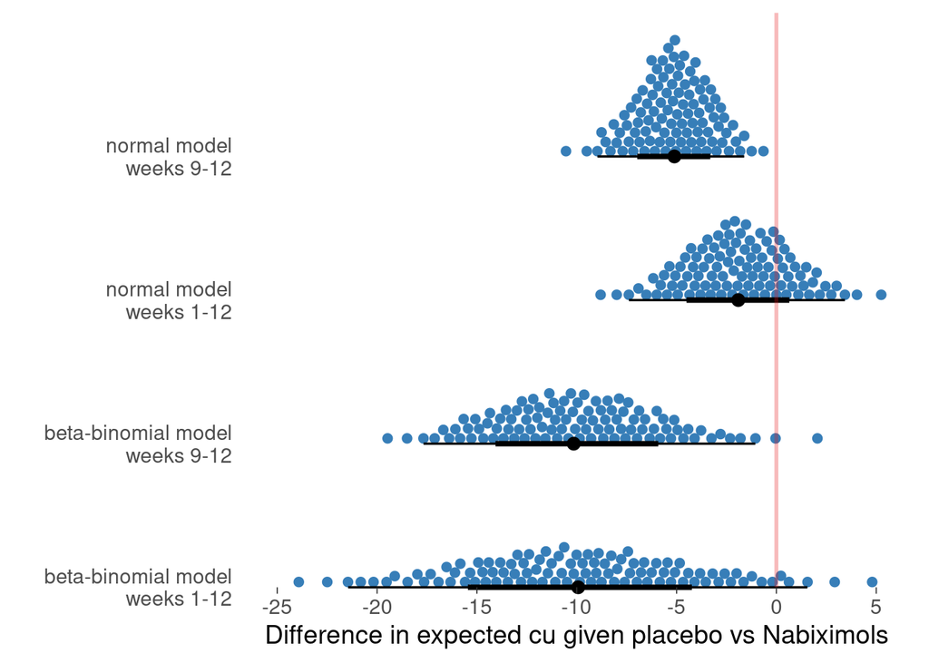

Figure 27

```r
rbind(dat_bb2b, dat_n2b, dat_bb2c, dat_n2c) |>
  ggplot(aes(x = .epred, y = model)) +
  stat_dotsinterval(quantiles = 100, layout = "swarm", fill = set1[2], slab_color = set1[2]) +
  coord_cartesian(expand = FALSE, clip = "off") +
  theme(strip.background = element_blank(), strip.placement = "outside",
        legend.position = "none") +
  scale_x_continuous(lim = c(-27, 7), breaks = seq(-25, 5, by = 5)) +
  labs(x = "Difference in expected cu given placebo vs Nabiximols", y = "") +
  geom_vline(xintercept = 0, color = set1[1], linewidth = 1, alpha = 0.3) +
  theme(axis.line.y = element_blank(),
        axis.ticks.y = element_blank(),
        axis.line.x = element_blank())
```

The normal models underestimate the magnitude of the change and are overconfident having much narrower posteriors. When we compare posteriors for effect in weeks 9-12 given the models which included week as a covariate, the conclusion about benefit of Nabiximols is the same with normal and beta-binomial model despite that the normal model underestimates the effect. When we compare posteriors for effect in weeks 1-12 given the models which did not include week as a covariate, the conclusion on benefit of Nabiximols is clearly different. In this case, we know based on LOO-CV comparisons and posterior predictive checking that the beta-binomial has much better performance and matches the data much better, and we can safely drop the normal models from consideration. The conclusions using the models with week as a covariate or all counts summed together are similar, although focusing in the last four week period gives sharper posterior which is plausible as the effect seems to be increasing in time.

The results here are illustrating that the choice of data model can matter for the conclusions, but also the best models shown here could be even further improved by using the additional data used by Lintzeris et al. (2020).

# 16 Predictive performance comparison

Above, posterior predictive checking, LOO predictive checking, and LOO-ELPD comparisons were important for model checking and comparison, and only after we trusted that there is no significant discrepancy between the model predictions and the data, we did look at the treatment effect. We used LOO model comparison to assess the the more elaborate models did provide better predictions, but we did not use it above for assessing the predictive performance of using the treatment effect in the model.

Let’s now build the mode without treatment group variable and check whether there is significant difference in predictive performance.

```r
fit_betabinomial3b <- brm(cu | trials(set) ~ week + cu_baseline + (1 | id),
        data = cu_df_b,
        beta_binomial(),
        prior = c(prior(normal(0, 9), class = Intercept),
                  prior(normal(0, 3), class = b)),
        save_pars = save_pars(all = TRUE),
        seed = 1234,
        refresh = 0)
```

```
Running MCMC with 4 parallel chains...

Chain 2 finished in 4.3 seconds.
Chain 1 finished in 4.6 seconds.
Chain 4 finished in 4.9 seconds.
Chain 3 finished in 6.1 seconds.

All 4 chains finished successfully.
Mean chain execution time: 5.0 seconds.
Total execution time: 6.3 seconds.
```

```r
fit_betabinomial3b <- add_criterion(fit_betabinomial3b, criterion = "loo",
                                    save_psis = TRUE, moment_match = TRUE)
```

We compare the models with and without group variable:

```r
loo_compare(fit_betabinomial2b, fit_betabinomial3b)
```

```
              model elpd_diff se_diff p_worse       diag_diff      diag_elpd
 fit_betabinomial3b       0.0     0.0      NA                 3 k_psis > 0.7
 fit_betabinomial2b       0.0     2.4    0.51 |elpd_diff| < 4 3 k_psis > 0.7
```

There are a few high Pareto k values for PSIS-LOO even after moment matching, and for final results we would use also `reloo=TRUE` argument, but the conclusions are likely to be the same.

There is a negligible difference in predictive performance for predicting cannabis use in a 4-week period for a new person. This is probably due to 1. the actual effect not being very far from 0, 2. the aleatoric uncertainty (modelled by the beta-binomial) for a new 4-week period is big, that is the predictive distribution is very wide and due to the constrained range has also thick tails (actually U shape), which makes the log score not sensitive in the tails.

As the predictive distribution is wide with thick tails, we can also focus on comparing absolute error of using means of the predictive distributions as point estimates. This approach has the benefit that we can improve accuracy of the finite MCMC sample by dropping the sampling from the varying intercept population distribution and from the beta-binomial distribution (using `posterior_epred(, re_formula=NA)`. `E_loo` is used to go from posterior predictive draws to the mean of leave-one-out predictive distribution.

```r
ae2 <- abs(cu_df_b$cu - E_loo(posterior_epred(fit_betabinomial2b, re_formula = NA),
                              loo(fit_betabinomial2b)$psis_object, type = "mean")$value)
ae3 <- abs(cu_df_b$cu - E_loo(posterior_epred(fit_betabinomial3b, re_formula = NA),
                              loo(fit_betabinomial3b)$psis_object, type = "mean")$value)
```

Probability that the leave-one-out predictive absolute error is smaller with model 2b (with group variable) than with model 3b (without group variable) using normal approximation.

```r
pnorm(0, mean(ae2-ae3), sd(ae2-ae3)/sqrt(257)) |> round(2)
```

```
[1] 0.96
```

By dropping out the aleatoric part from the LOO-CV predictions we do see clear difference in the predictive performance if the treatment group variable is dropped, but still the randomness in the actual observations makes the probability of the difference to be further away from 1 than when we focused in the expected counterfactual predictions above.

We don’t usually use Bayes factors for many reasons, but for completeness we used `bridgesampling` (Gronau, Singmann, and Wagenmakers 2020) to get estimated Bayes factor.

```r
(br2b <- bridgesampling::bridge_sampler(fit_betabinomial2b, silent = TRUE))
```

```
Bridge sampling estimate of the log marginal likelihood: -607.3502
Estimate obtained in 8 iteration(s) via method "normal".
```

```r
(br3b <- bridgesampling::bridge_sampler(fit_betabinomial3b, silent = TRUE))
```

```
Bridge sampling estimate of the log marginal likelihood: -606.2498
Estimate obtained in 10 iteration(s) via method "normal".
```

```r
bridgesampling::bf(br2b, br3b)
```

```
Estimated Bayes factor in favor of br2b over br3b: 0.33272
```

Like LOO-CV, Bayes factor does not see difference between models with or without treatment group variable. Bayes factor is a ratio of marginal likelihoods, and marginal likelihoods can be formulated as sequential log score predictive performance quantity, which explains why BF is also weak to rank models in case of high aleatoric uncertainty.

# References

Bürkner, Paul-Christian. 2017. “brms: An R Package for Bayesian Multilevel Models Using Stan.” *Journal of Statistical Software* 80 (1): 1–28. https://doi.org/10.18637/jss.v080.i01.

Dimitriadis, Timo, Tilmann Gneiting, and Alexander I. Jordan. 2021. “Stable Reliability Diagrams for Probabilistic Classifiers.” *Proceedings of the National Academy of Sciences* 118 (8): e2016191118.

Gronau, Quentin F., Henrik Singmann, and Eric-Jan Wagenmakers. 2020. “bridgesampling: An R Package for Estimating Normalizing Constants.” *Journal of Statistical Software* 92 (10): 1–29. https://doi.org/10.18637/jss.v092.i10.

Kallioinen, Noa, Topi Paananen, Paul-Christian Bürkner, and Aki Vehtari. 2023. “Detecting and Diagnosing Prior and Likelihood Sensitivity with Power-Scaling.” *Statistics and Computing* 34 (1): 57.

Kay, Matthew. 2023. *tidybayes: Tidy Data and Geoms for Bayesian Models*. https://doi.org/10.5281/zenodo.1308151.

———. 2024. *ggdist: Visualizations of Distributions and Uncertainty*. https://doi.org/10.5281/zenodo.3879620.

Lintzeris, Nicholas, Anjali Bhardwaj, Llewellyn Mills, Adrian Dunlop, Jan Copeland, Iain McGregor, Raimondo Bruno, et al. 2019. “Nabiximols for the Treatment of Cannabis Dependence: A Randomized Clinical Trial.” *JAMA Internal Medicine* 179 (9): 1242–53.

Lintzeris, Nicholas, Llewellyn Mills, Adrian Dunlop, Jan Copeland, Iain Mcgregor, Raimondo Bruno, Adrienne Kirby, et al. 2020. “Cannabis Use in Patients 3 Months After Ceasing Nabiximols for the Treatment of Cannabis Dependence: Results from a Placebo-Controlled Randomised Trial.” *Drug and Alcohol Dependence* 215 (108220).

Paananen, Topi, Juho Piironen, Paul-Christian Bürkner, and Aki Vehtari. 2021. “Implicitly Adaptive Importance Sampling.” *Statistics and Computing* 31 (16).

Säilynoja, Teemu, Paul-Christian Bürkner, and Aki Vehtari. 2022. “Graphical Test for Discrete Uniformity and Its Applications in Goodness-of-Fit Evaluation and Multiple Sample Comparison.” *Statistics and Computing* 32: 1573–375.

Vehtari, Aki, Jonah Gabry, Mans Magnusson, Yuling Yao, Paul-Christian Bürkner, Topi Paananen, and Andrew Gelman. 2024. “Loo: Efficient Leave-One-Out Cross-Validation and WAIC for Bayesian Models.” https://mc-stan.org/loo/.

Vehtari, Aki, Andrew Gelman, and Jonah Gabry. 2017. “Practical Bayesian Model Evaluation Using Leave-One-Out Cross-Validation and WAIC.” *Statistics and Computing* 27: 1413–32.

Vehtari, Aki, Daniel Simpson, Andrew Gelman, Yuling Yao, and Jonah Gabry. 2024. “Pareto Smoothed Importance Sampling.” *Journal of Machine Learning Research* 25 (72): 1–58.

# Licenses

- Code © 2024, Aki Vehtari, licensed under BSD-3.
- Text © 2024, Aki Vehtari, licensed under CC-BY-NC 4.0.